# Projet Info-Stat UE MI0A403T

Gandon Nuala, Buisson Pensee, Gateka Pia Lathia

2025-05-06

# Introduction

Ce rapport a été réalisé dans le cadre du projet de l’UE MI0A403T - Projet Info-Stat. Il a été mené par un groupe de trois étudiantes, Nuala GANDON, Pia Lathia Gateka et Pensée Buisson. Le but de ce projet est de construire une base de données pour stocker et gérer des données liées aux incendies, puis d’en extraire des informations pour en faire une analyse statistique descriptive, à la fois univariée et bivariée. Le rapport présente les différentes étapes du travail effectué, depuis la construction de la base jusqu’à l’analyse des données.

# Base de données

## Construction de la base de données

### Création de la structure de la base de données

Nous avons construit une base de données **SQLite** contenant trois tables : `Communes`, `Incendies`, et `Donnees_Meteos`.

La création des tables est réalisée avec le code suivant :

```python
import sqlite3
import csv

def connect(nom_base):
    bd = sqlite3.connect(nom_base)
    curs = bd.cursor()
    curs.executescript("""
        CREATE TABLE IF NOT EXISTS Communes (
            code_INSEE CHAR(5),
            altitude_med INT,
            latitude FLOAT,
            longitude FLOAT,
            PRIMARY KEY(code_INSEE)
        );

        CREATE TABLE IF NOT EXISTS Incendies (
            id INTEGER PRIMARY KEY AUTOINCREMENT,
            commune VARCHAR(40),
            code_INSEE CHAR(5),
            surface_parcouru_m2 INT,
            annee INT,
            mois CHAR(3),
            jour INT,
            heure INT,
            nature_primaire VARCHAR(20),
            nature_secondaire VARCHAR(20) DEFAULT 'NA',
            FOREIGN KEY (code_INSEE) REFERENCES Communes(code_INSEE),
            CHECK(heure BETWEEN 0 AND 23),
            CHECK(jour BETWEEN 1 AND 31)
        );

        CREATE TABLE IF NOT EXISTS Donnees_Meteos (
            code_INSEE CHAR(5),
            RR_MED FLOAT,
            NBJRR1_MED FLOAT,
            NBJRR5_MED FLOAT,
            NBJRR10_MED FLOAT,
            Tmin_MED FLOAT,
            Tmax_MED FLOAT,
            tens_vap_MED FLOAT,
            force_vent_MED FLOAT,
            insolation_MED VARCHAR(10) DEFAULT 'NA',
            rayonnement_MED VARCHAR(10) DEFAULT 'NA',
            PRIMARY KEY(code_INSEE),
            FOREIGN KEY(code_INSEE) REFERENCES Communes(code_INSEE),
            CHECK(RR_MED >= 0),
            CHECK(NBJRR1_MED >= 0),
            CHECK(NBJRR5_MED >= 0),
            CHECK(NBJRR10_MED >= 0),
            CHECK(tens_vap_MED >= 0),
            CHECK(force_vent_MED >= 0)
        );
    """)
    bd.commit()
    return bd, curs

# Connexion à la base
db, curs = connect("../BDprojet.db")
```

**Explications du code :**

- Connexion à la base de données SQLite : La fonction `connect()` établit une connexion avec une base de données locale nommée `BDprojet.db`. Si elle n’existe pas, elle est automatiquement créée.
- Création des tables :
  - `Communes` : enregistre pour chaque commune son code INSEE, son altitude moyenne, sa latitude et sa longitude.
  - `Incendies` : stocke les caractéristiques des incendies (surface parcourue, date, heure, type d’incendie) et référence la commune correspondante via une clé étrangère (`code_INSEE`).
  - `Donnees_Meteos` : contient des indicateurs météorologiques par commune (précipitations, température, vent, etc.) et référence la commune correspondante via une clé étrangère (`code_INSEE`).
- Gestion de l’intégrité des données :
  - Chaque table dispose de clés primaires (`code_INSEE` ou `id`) pour garantir l’unicité des enregistrements.
  - Des clés étrangères assurent la cohérence entre les incendies et les communes.
  - Des contraintes de vérification (`CHECK`) imposent des règles sur certaines colonnes (par exemple, les heures doivent être comprises entre 0 et 23).
- L’ensemble des commandes SQL est exécuté à l’aide de `executescript()` et le modifications sont sauvegardés via `commit()`.

### Insertion de données dans la base de données

Après la création de la structure de la base de données, nous avons inséré les données provenant de fichiers CSV.

#### Insertion des données géographiques (Table Communes)

```python
curs.execute("SELECT COUNT(*) FROM Communes")
```

```
## <sqlite3.Cursor object at 0x000001FF14988FC0>
```

```python
if curs.fetchone()[0] == 0:         # Si vide
    with open("../donnees_geo.csv") as file :
        reader_communes = csv.DictReader(file)
        for row in reader_communes:
            code_insee = row['code_INSEE']
            latitude = float(row['latitude'])
            longitude = float(row['longitude'])
            altitude = int(row['altitude_med'])

            curs.execute("""INSERT INTO Communes(code_INSEE, latitude, longitude,
              altitude_med) VALUES (?, ?, ?, ?)""",
              (code_insee, latitude, longitude, altitude))
            db.commit()
```

**Explications du code :** Dans ce code, nous vérifions avant insertion si la table Communes est vide :

- `curs.execute("SELECT COUNT(*) FROM Communes")` : Cette requête compte le nombre de lignes existantes dans la table `Communes`.
- `if curs.fetchone()[0] == 0:` : Si la table est vide (aucune donnée présente), alors nous procédons à l’insertion des données.
- `csv.DictReader(file)` : Le fichier CSV `donnees_geo.csv` est lu sous forme de dictionnaire, ce qui facilite l’accès aux colonnes par leur nom.
- Pour chaque ligne du fichier, on :
  - Extrait : `code_INSEE`, `latitude`, `longitude`, et `altitude`.
  - Convertit : les types de données sont adaptés (float pour latitude et longitude, int pour altitude).
  - Insère : avec une requête `INSERT INTO Communes`, en utilisant des paramètres `?` pour éviter toute injection SQL.
  - Sauvegarde : chaque insertion est validée dans la base par `db.commit()`.

Le contrôle avant l’insertion empêche insertions multiples accidentelles en cas de relance du script, et garantit que les données ne sont insérées qu’une seule fois.

#### Insertion des données d’incendies (Table Incendies)

```python
curs.execute("SELECT COUNT(*) FROM Incendies")
```

```
## <sqlite3.Cursor object at 0x000001FF14988FC0>
```

```python
if curs.fetchone()[0] == 0:
    with open("../donnees_incendies.csv") as file:
        reader_incendies = csv.DictReader(file)
        for row in reader_incendies:
            commune = row['commune']
            code_insee = row['code_INSEE']
            surface_parcourue = int(row['surface_parcourue_m2'])
            annee = int(row['annee'])
            mois = row['mois']
            jour = int(row['jour'])
            heure = int(row['heure'])
            nature_inc_prim = row['nature_inc_prim']
            nature_inc_sec = row['nature_inc_sec']

            curs.execute("""INSERT INTO Incendies(commune,code_INSEE,surface_parcouru_m2,annee,mois,jour,heure,nature_primaire,nature_secondaire) VALUES (?,?,?,?,?,?,?,?,?)""",
                        (commune,code_insee,surface_parcourue,annee,mois,jour,heure,nature_inc_prim,nature_inc_sec))
            db.commit()
```

**Explications du code :** Dans ce code, nous vérifions avant insertion si la table Incendies est vide :

- `curs.execute("SELECT COUNT(*) FROM Incendies")` : Cette requête compte le nombre de lignes existantes dans la table `Incendies`.
- `if curs.fetchone()[0] == 0:` : Si la table est vide (aucune donnée présente), alors nous procédons à l’insertion des données.
- `csv.DictReader(file)` : Le fichier CSV `donnees_incendies.csv` est lu sous forme de dictionnaire, ce qui facilite l’accès aux colonnes par leur nom.
- Pour chaque ligne du fichier, on :
  - Extrait : `commune`, `code_INSEE`, `surface_parcourue_m2`, `annee`, `mois`, `jour`, `heure`, `nature_inc_prim`, `nature_inc_sec`.
  - Convertit : les types de données sont adaptés (int pour `surface_parcourue_m2`, `annee`, `jour`, `heure`).
  - Insère : avec une requête `INSERT INTO Incendies`, en utilisant des paramètres `?` pour éviter toute injection SQL.
  - Sauvegarde : chaque insertion est validée dans la base par `db.commit()`.

Le contrôle avant l’insertion empêche insertions multiples accidentelles en cas de relance du script, et garantit que les données ne sont insérées qu’une seule fois.

#### Insertion des données météorologiques (Table Donnees_Meteos)

```python
def convert_float(value):
    try:
        return(float(value))
    except (ValueError,TypeError):
        return None

curs.execute("SELECT COUNT(*) FROM Donnees_Meteos")
```

```
## <sqlite3.Cursor object at 0x000001FF14988FC0>
```

```python
if curs.fetchone()[0] == 0:
    with open("../donnees_meteo.csv") as file:
        reader_meteo = csv.DictReader(file)
        for row in reader_meteo:
            code_insee = row['Code.INSEE']
            rr = convert_float(row['RR_med'])
            nbjrr1 = convert_float(row['NBJRR1_med'])
            nbjrr5 = convert_float(row['NBJRR5_med'])
            nbjrr10 = convert_float(row['NBJRR10_med'])
            tmin =convert_float(row['Tmin_med'])
            tmax = convert_float(row['Tmax_med'])
            tens_vap = convert_float(row['Tens_vap_med'])
            force_vent = convert_float(row['Force_vent_med'])
            insolation = row['Insolation_med']
            rayonnement = row['Rayonnement_med']

            curs.execute("""INSERT INTO Donnees_Meteos(code_INSEE,RR_MED,NBJRR1_MED,NBJRR5_MED,NBJRR10_MED,Tmin_MED,Tmax_MED,tens_vap_MED,force_vent_MED,insolation_MED,rayonnement_MED) VALUES (?,?,?,?,?,?,?,?,?,?,?)""",
                        (code_insee,rr,nbjrr1,nbjrr5,nbjrr10,tmin,tmax,tens_vap,force_vent,insolation,rayonnement))
            db.commit()
```

- `curs.execute("SELECT COUNT(*) FROM Donnees_Meteos")` : Cette requête compte le nombre de lignes existantes dans la table `Donnees_Meteos`.
- `if curs.fetchone()[0] == 0:` : Si la table est vide (aucune donnée présente), alors nous procédons à l’insertion des données.
- `csv.DictReader(file)` : Le fichier CSV `donnees_meteo.csv` est lu sous forme de dictionnaire, ce qui facilite l’accès aux colonnes par leur nom.
- Pour chaque ligne du fichier, on :
  - Extrait : `Code.INSEE`, `RR_med`, `NBJRR1_med`, `NBJRR5_med`, `NBJRR10_med`, `Tmin_med`, `Tmax_med`, `Tens_vap_med`, `Force_vent_med`, `Insolation_med`, `Rayonnement_med`.
  - Convertit : les types de données sont adaptés (float pour `rr`, `nbjrr1`, `nbjrr5`, `nbjrr10`, `tmin`, `tmax`, `tens_vap`, `force_vent`) à l’aide de la fonction `convert_float(value)`.
  - Insère : avec une requête `INSERT INTO Donnees_Meteos`, en utilisant des paramètres `?` pour éviter toute injection SQL.
  - Sauvegarde : chaque insertion est validée dans la base par `db.commit()`.

Le contrôle avant l’insertion empêche insertions multiples accidentelles en cas de relance du script, et garantit que les données ne sont insérées qu’une seule fois.

## Extractions de tables depuis la base de données

Après l’insertion des données dans la base de données, nous avons extrait les tables dont on se servira pour les études univariées et bivariées.

### Extraction des variables pour l’analyse univariée

Pour réaliser l’analyse univariée des 10 variables sélectionnées, nous avons regroupé toutes les données nécessaires dans une table unique issue de la jointure des tables `Incendies`, `Communes` et `Donnees_Meteos`. Les données sont exportées dans un fichier CSV dédié.

```python
with open('../Exports/variables_analyses_univarie.csv', mode="w", newline='') as file:
    writer = csv.writer(file)
    writer.writerow(['surface_parcouru_m2','Tmax_MED','RR_MED','force_vent_MED','nature_primaire','nature_secondaire','mois','annee','altitude_med','NBJRR1_MED'])

    curs.execute("""
        SELECT i.surface_parcouru_m2, d.Tmax_MED, d.RR_MED, d.force_vent_MED, i.nature_primaire,i.nature_secondaire, i.mois, i.annee, c.altitude_med, d.NBJRR1_MED
        FROM Incendies i
        INNER JOIN Communes c ON i.code_INSEE = c.code_INSEE
        INNER JOIN Donnees_Meteos d ON i.code_INSEE = d.code_INSEE;
    """)

    resultats = curs.fetchall()
    writer.writerows(resultats)
```

```
## 121
## <sqlite3.Cursor object at 0x000001FF14988FC0>
```

### Extraction des variables pour les analyses bivariées

#### Relation entre la force du vent et la surface brûlée

Ce bloc extrait les données nécessaires pour étudier l’impact de la force moyenne du vent sur la surface parcourue par les incendies.

```python
with open('../Exports/surface_vs_force_vent.csv', mode="w", newline='') as file:
    writer = csv.writer(file)
    writer.writerow(['surface_parcouru_m2','force_vent_MED'])

    curs.execute("""
        SELECT i.surface_parcouru_m2, d.force_vent_MED
        FROM Incendies i
        INNER JOIN Donnees_Meteos d ON i.code_INSEE = d.code_INSEE
    """)

    resultats = curs.fetchall()
    writer.writerows(resultats)
```

```
## 36
## <sqlite3.Cursor object at 0x000001FF14988FC0>
```

#### Relation entre température maximale et surface parcourue

Ce bloc extrait les données nécessaires pour étudier l’existence d’un lien entre la température maximale moyenne et la surface brûlée.

```python
with open('../Exports/surface_vs_Tmax.csv', mode="w", newline='') as file:
    writer = csv.writer(file)
    writer.writerow(['surface_parcouru_m2','Tmax_MED'])

    curs.execute("""
        SELECT i.surface_parcouru_m2, d.Tmax_MED
        FROM Incendies i
        INNER JOIN Donnees_Meteos d ON i.code_INSEE = d.code_INSEE
    """)

    resultats = curs.fetchall()
    writer.writerows(resultats)
```

```
## 30
## <sqlite3.Cursor object at 0x000001FF14988FC0>
```

#### Relation entre nature primaire et surface parcourue

Ce bloc extrait les données nécessaires pour étudier la relation entre la nature primaire d’un incendie et la surface brûlée.

```python
with open('../Exports/surface_vs_nature_primaire.csv', mode="w", newline='') as file:
    writer = csv.writer(file)
    writer.writerow(['nature_primaire','surface_parcourue_m2'])

    curs.execute("""
        SELECT i.nature_primaire, i.surface_parcouru_m2
        FROM Incendies i
    """)

    resultats = curs.fetchall()
    writer.writerows(resultats)
```

```
## 38
## <sqlite3.Cursor object at 0x000001FF14988FC0>
```

#### Relation entre la période de l’année et la surface parcourue

Ce bloc extrait les données nécessaires pour étudier la relation entre la mois de l’année et la surface brûlée par les incendies.

```python
with open('../Exports/surface_vs_mois.csv', mode="w", newline='') as file:
    writer = csv.writer(file)
    writer.writerow(['id','code_INSEE','surface_parcouru_m2', 'mois'])

    curs.execute("""
        SELECT id, code_INSEE, surface_parcouru_m2, mois
        FROM Incendies
    """)

    resultats = curs.fetchall()
    writer.writerows(resultats)
```

```
## 40
## <sqlite3.Cursor object at 0x000001FF14988FC0>
```

#### Relation entre la latitude des communes et la surface parcourue

Ce bloc extrait les données nécessaires pour étudier la relation entre la latitude des communes touchées par des incendies et la surface brûlée par les incendies.

```python
with open('../Exports/surface_vs_latitude.csv', mode="w", newline='') as file:
    writer = csv.writer(file)
    writer.writerow(['surface_parcouru_m2', 'latitude'])

    curs.execute("""
        SELECT i.surface_parcouru_m2, c.latitude
        FROM Incendies i
        INNER JOIN Communes c ON i.code_INSEE = c.code_INSEE
    """)

    resultats = curs.fetchall()
    writer.writerows(resultats)
```

```
## 30
## <sqlite3.Cursor object at 0x000001FF14988FC0>
```

Après l’extraction des données nécessaires à notre analyse, on ferme le curseur.

```python
curs.close()
```

# Statistique descriptive

## Appropriation des données : Étude descriptive des variables

### Chargement des données

```r
donnees_incendies <- read.csv("../Exports/variables_analyses_univarie.csv",
                              encoding = "UTF-8", stringsAsFactors = TRUE)
View(donnees_incendies)
```

### Variable Surface parcourue (en m²)

#### Indicateurs numériques

**Calcul de la moyenne**

```r
mean(donnees_incendies$surface_parcouru_m2, na.rm = TRUE)
```

```
## [1] 179540.1
```

**Calcul de l’écart-type**

```r
sd(donnees_incendies$surface_parcouru_m2, na.rm = TRUE)
```

```
## [1] 182220.1
```

**Calcul de la variance**

```r
var(donnees_incendies$surface_parcouru_m2, na.rm = TRUE)
```

```
## [1] 33204180784
```

**Plus petite valeur**

```r
min(donnees_incendies$surface_parcouru_m2, na.rm = TRUE)
```

```
## [1] 50000
```

**Plus grande valeur**

```r
max(donnees_incendies$surface_parcouru_m2, na.rm = TRUE)
```

```
## [1] 1000000
```

**Vecteur contenant le minimum et le maximum**

```r
range(donnees_incendies$surface_parcouru_m2, na.rm = TRUE)
```

```
## [1]   50000 1000000
```

**Calcul de la médiane**

```r
median(donnees_incendies$surface_parcouru_m2, na.rm = TRUE)
```

```
## [1] 102830.5
```

**Résumé de la variable surface_parcourue_m2**

```r
summary(donnees_incendies$surface_parcouru_m2)
```

```
##    Min. 1st Qu.  Median    Mean 3rd Qu.    Max.
##   50000   69519  102831  179540  204950 1000000
```

L’analyse des indicateurs numériques de la variable `surface_parcourue_m2` montre que la superficie moyenne parcourue par les incendies est de **179 540 m²**, tandis que la médiane est de **102 830,5 m²**. La moyenne étant nettement supérieure à la médiane, cela indique que la distribution est asymétrique vers la droite, suggérant la présence de quelques incendies de très grande ampleur qui influencent fortement la moyenne.

La dispersion des valeurs est également très importante, comme en témoigne un écart-type élevé de **182 220,1 m²**. Cela traduit une grande variabilité dans les surfaces parcourues par les incendies. La variance (33 204 180 784 (m²)²) confirme cette importante dispersion, bien que cette mesure soit moins intuitive que l’écart-type.

Concernant les valeurs extrêmes, les incendies recensés couvrent des superficies comprises entre **50 000 m²** et **1 000 000 m²**, ce qui indique que seuls des événements de grande ampleur sont présents dans cet ensemble de données. Le premier quartile se situe à **69 519 m²** et le troisième quartile à **204 950 m²**, montrant que la moitié des incendies a parcouru des superficies comprises entre ces deux valeurs.

En conclusion, les incendies de l’échantillon étudié présentent des surfaces globalement élevées, avec une distribution très étalée et marquée par quelques événements exceptionnels.

#### Représentations graphiques

##### Boîte-à-moustache

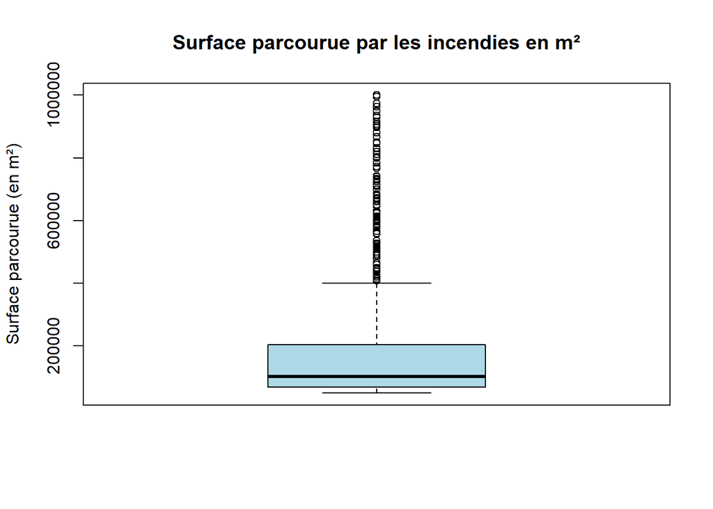

```r
options(scipen = 10) # permet de privilégier l'affichage des nombres en format normal plutôt qu'en notation scientifique, afin de rendre la lecture des valeurs sur l'axe des ordonnées plus lisible.
boxplot(donnees_incendies$surface_parcouru_m2,
        main = "Surface parcourue par les incendies en m²",
        ylab = "Surface parcourue (en m²)",
        col = "lightblue")
```

Le boxplot de la variable `surface_parcouru_m2` montre une forte asymétrie à droite, ce qui est cohérent avec les résultats numériques obtenus précédemment. La majorité des incendies parcourent des surfaces comprises entre le premier et le troisième quartile, avec une médiane autour de 100 000 m². On observe la présence de nombreuses valeurs extrêmes, correspondant à des incendies de grande ampleur dépassant largement les surfaces habituelles. Ces valeurs extrêmes expliquent l’écart important entre la médiane et la moyenne, ainsi que la forte dispersion observée dans l’analyse descriptive. Ainsi, la distribution de la surface parcourue est dominée par un grand nombre de feux de taille modérée, mais influencée par quelques événements exceptionnels.

##### Histogramme

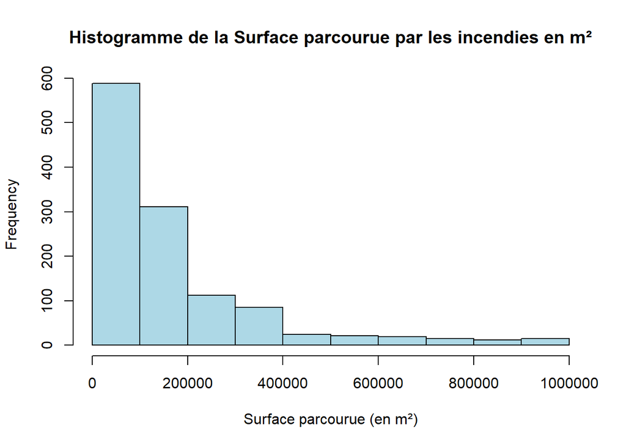

```r
hist(donnees_incendies$surface_parcouru_m2,
        main = "Histogramme de la Surface parcourue par les incendies en m²",
        xlab = "Surface parcourue (en m²)",
        col = "lightblue")
```

L’histogramme de la `surface_parcouru_m2` par les incendies montre une forte asymétrie à droite. La majorité des incendies parcourent des surfaces inférieures à 200 000 m². Le nombre d’incendies diminue rapidement avec l’augmentation de la surface parcourue. Quelques incendies exceptionnels couvrent de très grandes surfaces. La présence de ces valeurs extrêmes confirme les observations réalisées sur le boxplot précédent. La distribution présente une longue traîne à droite, traduisant la rareté des grands incendies. L’ensemble confirme une forte concentration des valeurs autour de petites surfaces.

#### Conclusion

L’analyse univariée de la variable `surface_parcourue_m2` révèle une distribution fortement asymétrique à droite, dominée par une majorité d’incendies de taille modérée, mais fortement influencée par quelques événements exceptionnels de très grande ampleur. Cette asymétrie est confirmée tant par les indicateurs statistiques (écart marqué entre moyenne et médiane, forte dispersion) que par les représentations graphiques (boxplot et histogramme). Ainsi, bien que la majorité des incendies parcourent des surfaces inférieures à 200 000 m², la présence de feux extrêmes, rares mais étendus, joue un rôle déterminant dans la structure de la distribution.

### Variable Tmax_MED

#### Indicateurs numériques

**Calcul de la moyenne**

```r
mean(donnees_incendies$Tmax_MED, na.rm = TRUE)
```

```
## [1] 18.08116
```

**Calcul de l’écart-type**

```r
sd(donnees_incendies$Tmax_MED, na.rm = TRUE)
```

```
## [1] 2.92036
```

**Calcul de la variance**

```r
var(donnees_incendies$Tmax_MED, na.rm = TRUE)
```

```
## [1] 8.528502
```

**Plus petite valeur**

```r
min(donnees_incendies$Tmax_MED, na.rm = TRUE)
```

```
## [1] 2
```

**Plus grande valeur**

```r
max(donnees_incendies$Tmax_MED, na.rm = TRUE)
```

```
## [1] 33.65
```

**Vecteur contenant le minimum et le maximum**

```r
range(donnees_incendies$Tmax_MED, na.rm = TRUE)
```

```
## [1]  2.00 33.65
```

**Calcul de la médiane**

```r
median(donnees_incendies$Tmax_MED, na.rm = TRUE)
```

```
## [1] 18.8
```

**Résumé de la variable surface_parcourue_m2**

```r
summary(donnees_incendies$Tmax_MED)
```

```
##    Min. 1st Qu.  Median    Mean 3rd Qu.    Max.
##    2.00   16.70   18.80   18.08   19.70   33.65
```

L’analyse des indicateurs numériques de la variable `Tmax_MED` représentant la température maximale moyenne mensuelle des communes où il y a eu des incendies révèle une température moyenne de **18.08°C**, tandis que la médiane est de **18.8°C**. La moyenne étant légèrement inférieure à la médiane, cela suggère une distribution globalement symétrique, avec une légère tendance à l’asymétrie vers les températures les plus basses, bien que cette différence reste très modérée.

La dispersion des température est modérée, avec un écart-type de **2.92°C**. Cela reflète une variabilité entre les communes, mais sans excès. La variance, estimée à **8.52 (°C)²**, confirme cette dispersion.

Concernant les valeurs extrêmes, les températures maximales moyennes mensuelles observées s’étendent de **2°C** à **33.65°C**, ce qui montre une forte amplitude thermique entre les communes les plus fraîches et les plus chaudes concernées par les incendies. Le premier quartile se situe à **16.7°C** et le troisième quartile à **19.7°C**, ce qui signifie que la moitié des communes touchées par des incendies présentent des températures maximales médianes comprises entre ces deux bornes.

En conclusion, les températures maximales moyennes mensuelles des communes touchées par les incendies sont globalement modérées à élevées, avec une variabilité modérée. La faible différence entre la moyenne et la médiane suggère une distribution globalement symétrique avec uen très légère inclinaison vers les températures les plus basses.

#### Représentation graphique

##### Boîte-à-moustache

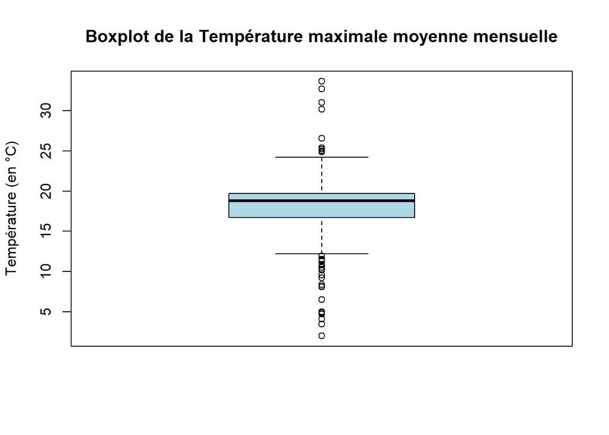

```r
boxplot(donnees_incendies$Tmax_MED,
        main = "Boxplot de la Température maximale moyenne mensuelle",
        ylab = "Température (en °C)",
        col = "lightblue")
```

Le boxplot de la variable `Tmax_MED`, représentant la température maximale moyenne mensuelle des communes touchées par des incendies, montre une distribution globalement symétrique avec une médiane proche de 19°C. La majorité des communes présentent des températures comprises entre 17 et 20°C, ce qui indique une variabilité modérée dans la majorité des cas. On observe toutefois la présence de valeurs extrêmes, notamment en desous de 10°C et au-dessus de 25°C, correspondant à des communes ayant des conditons climatiques soit beaucoup plus fraiches, soit beaucoup plus chaudes que la moyenne. Ainsi, il y a principalement des températures modérées dans la distribution des températures maximales mensuelles moyennes, tout en incluant quelques cas marginaux qui traduisent la diversité climatique des zones affectées par les incendies.

##### Histogramme

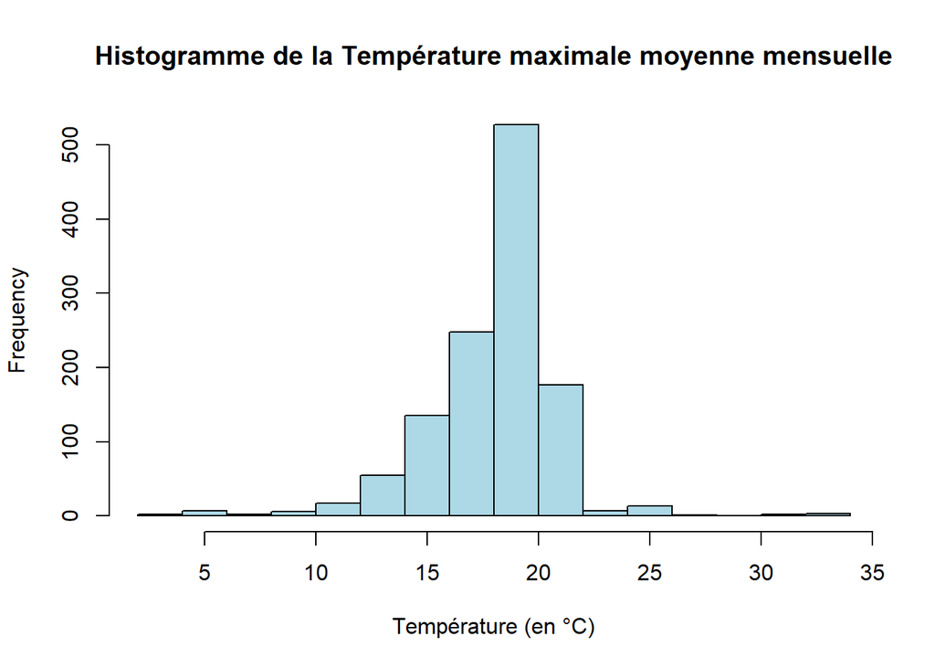

```r
hist(donnees_incendies$Tmax_MED,
        main = "Histogramme de la Température maximale moyenne mensuelle",
        xlab = "Température (en °C)",
        col = "lightblue")
```

L’histogramme de la variable `Tmax_MED` montre une distribution centrée autour de 18–20°C, avec une concentration marquée des valeurs entre 14°C et 22°C. La forme de la distribution est globalement symétrique, bien qu’une légère asymétrie vers les températures basses soit perceptible. Quelques valeurs extrêmes apparaissent en dessous de 10°C et au-dessus de 24°C. Cela traduit une variabilité modérée, avec des températures généralement homogènes.

#### Conclusion

L’analyse univariée de la variable `Tmax_MED` montre que les températures maximales moyennes mensuelles des communes touchées par les incendies sont globalement modérées à élevées, avec une moyenne de 18.08°C et une médiane légèrement supérieure à 18.8°C. Cette faible différence suggère une distribution globalement symétrique, légèrement inclinée vers les températures plus basses. La dispersion des données est modérée, comme en témoigne un écart-type de 2.92°C, et la majorité des températures se situent entre 16.7°C et 19.7°C.

Les représentations graphiques (boxplot et histogramme) confirment cette structure : une concentration importante autour de 18–20°C, avec quelques valeurs extrêmes en dehors de cette plage, traduisant la diversité climatique des zones concernées. En somme, Tmax_MED présente une distribution relativement homogène, ce qui reflète des conditions climatiques généralement similaires dans les communes touchées, bien que quelques cas atypiques, plus chauds ou plus froids, viennent nuancer ce constat.

### Variable RR_MED

#### Indicateurs numériques

**Calcul de la moyenne**

```r
mean(donnees_incendies$RR_MED, na.rm = TRUE)
```

```
## [1] 58.07953
```

**Calcul de l’écart-type**

```r
sd(donnees_incendies$RR_MED, na.rm = TRUE)
```

```
## [1] 28.26966
```

**Calcul de la variance**

```r
var(donnees_incendies$RR_MED, na.rm = TRUE)
```

```
## [1] 799.174
```

**Plus petite valeur**

```r
min(donnees_incendies$RR_MED, na.rm = TRUE)
```

```
## [1] 15.5
```

**Plus grande valeur**

```r
max(donnees_incendies$RR_MED, na.rm = TRUE)
```

```
## [1] 410.1
```

**Vecteur contenant le minimum et le maximum**

```r
range(donnees_incendies$RR_MED, na.rm = TRUE)
```

```
## [1]  15.5 410.1
```

**Calcul de la médiane**

```r
median(donnees_incendies$RR_MED, na.rm = TRUE)
```

```
## [1] 53
```

**Résumé de la variable surface_parcourue_m2**

```r
summary(donnees_incendies$RR_MED)
```

```
##    Min. 1st Qu.  Median    Mean 3rd Qu.    Max.
##   15.50   40.20   53.00   58.08   68.00  410.10
```

L’analyse des indicateurs numériques de la variable `RR_MED`, représentant le cumul mensuel moyen des hauteurs de précipitations pour les communes touchées par des incendies, révèle une moyenne de **58,08 mm**, tandis que la médiane s’élève à **53,00 mm**. La proximité de ces deux mesures suggère une distribution légèrement asymétrique à droite, ce que confirme la présence d’une valeur maximale très élevée (410,10 mm), significativement éloignée de la moyenne.

Par ailleurs, le premier quartile est de **40,20 mm** et le troisième quartile de **68,00 mm**, ce qui signifie que 50 % des communes ont un cumul mensuel moyen compris dans une fourchette interquartile de **27,8 mm**. Ce faible écart témoigne d’une dispersion modérée autour de la médiane.

L’écart-type s’élève à **28,27 mm**, avec une variance de **799,17 mm²**, et une étendue particulièrement large allant **de 15,50 mm à 410,10 mm**. Ces indicateurs confirment une variabilité importante des cumuls de précipitations entre les différentes communes concernées. Ils traduisent une hétérogénéité spatiale de la pluviométrie, certaines communes enregistrant des niveaux nettement supérieurs à la moyenne, possiblement en lien avec des spécificités géographiques ou microclimatiques locales.

#### Représentation graphique

##### Boîte-à-moustache

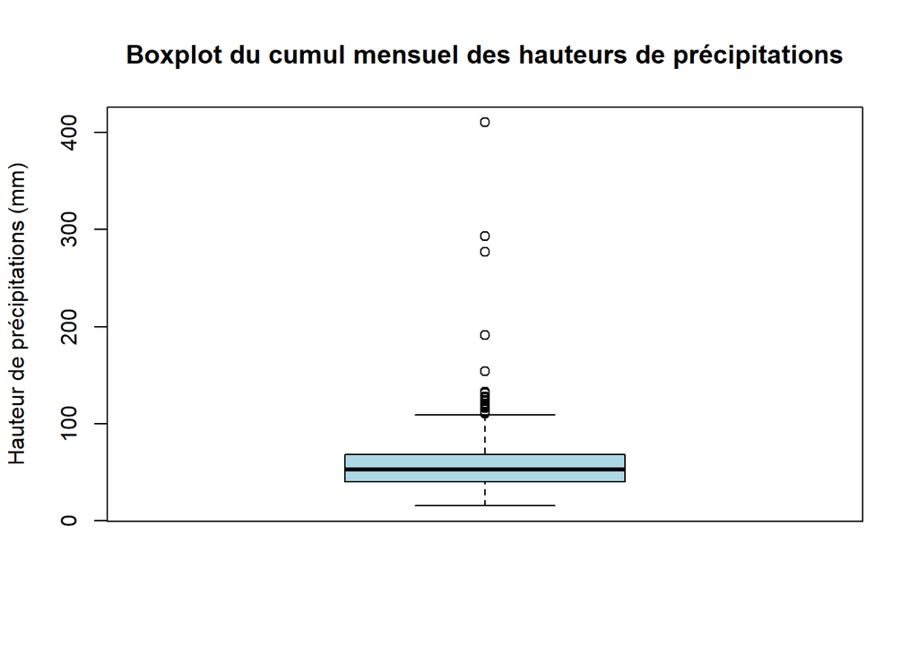

```r
boxplot(donnees_incendies$RR_MED,
        main = "Boxplot du cumul mensuel des hauteurs de précipitations",
        ylab = "Hauteur de précipitations (mm)",
        col = "lightblue")
```

Le boxplot illustre la distribution des valeurs de la variable `RR_MED`, correspondant au cumul mensuel des hauteurs de précipitations pour les communes ayant été affectées par des incendies.

Le corps de la boîte représente l’intervalle interquartile, c’est-à-dire les 50 % des valeurs comprises entre le 1er quartile (40,20 mm) et le 3e quartile (68,00 mm). La médiane, indiquée par la ligne noire à l’intérieur de la boîte, se situe à 53,00 mm, ce qui confirme visuellement la position centrale légèrement décalée vers le bas, cohérente avec une asymétrie à droite.

Les “moustaches” du boxplot s’étendent jusqu’aux valeurs extrêmes non considérées comme atypiques. Au-delà de ces bornes, plusieurs valeurs aberrantes sont visibles, dont certaines très éloignées du reste de la distribution, notamment une valeur extrême proche de 410 mm. Ces points indiquent que certaines communes enregistrent des précipitations exceptionnellement élevées, confirmant l’asymétrie positive déjà identifiée dans l’analyse statistique.

Enfin, la concentration des valeurs dans la boîte et la relative faible largeur de l’intervalle interquartile reflètent une dispersion modérée de la majorité des données, contrastant avec la présence de quelques communes aux conditions pluviométriques singulières.

##### Histogramme

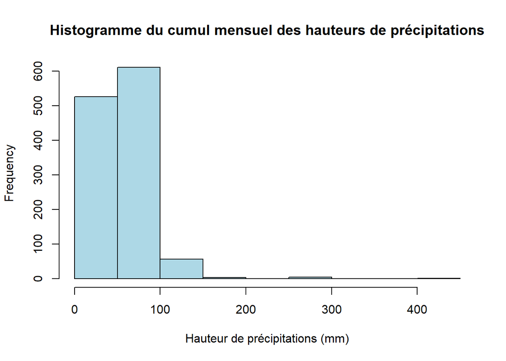

```r
hist(donnees_incendies$RR_MED,
     main = "Histogramme du cumul mensuel des hauteurs de précipitations",
     xlab = "Hauteur de précipitations (mm)",
     col = "lightblue")
```

L’histogramme illustre la distribution du cumul mensuel moyen des hauteurs de précipitations (en mm) pour les communes touchées par des incendies.

On observe une forte concentration des valeurs entre 0 mm et 100 mm, ce qui indique que la majorité des communes présentent des niveaux de précipitations relativement faibles à modérés. Cette répartition est cohérente avec la moyenne de 58,08 mm et la médiane de 53,00 mm, et reflète une distribution asymétrique vers la droite.

La diminution rapide de la fréquence à partir de 100 mm met en évidence l’existence de quelques communes ayant des cumuls mensuels de précipitations nettement plus élevés, parfois supérieurs à 200 mm, et dans certains cas, dépassant 400 mm. Bien que ces cas soient peu fréquents, ils contribuent à étirer la queue de la distribution vers les valeurs les plus élevées et expliquent l’écart entre la moyenne et la médiane.

En résumé, cette distribution indique que, parmi les communes touchées par les incendies, la majorité connaissent des niveaux de précipitations mensuelles modérés, tandis qu’un petit nombre d’entre elles se distinguent par des cumuls exceptionnellement élevés, contribuant ainsi à la variabilité globale de la variable étudiée.

#### Conclusion

L’analyse univariée de la variable `RR_MED`, représentant le cumul mensuel moyen des hauteurs de précipitations pour les communes touchées par des incendies, met en évidence une variabilité marquée des niveaux de précipitations d’une commune à l’autre. La distribution des valeurs est légèrement asymétrique vers la droite, avec une majorité de communes concentrées autour de valeurs modérées (entre 40 et 70 mm), mais aussi la présence de valeurs exceptionnellement élevées, qui influencent la moyenne.

Les indicateurs de dispersion (écart-type, étendue, quartiles) confirment cette hétérogénéité spatiale, tandis que les représentations graphiques (boxplot et histogramme) soulignent visuellement cette asymétrie et la prédominance des faibles précipitations dans la plupart des communes.

En somme, RR_MED présente une distribution globalement concentrée mais ponctuellement marquée par des valeurs très élevées.

### Variable force_vent_MED

#### Indicateurs numériques

**Calcul de la moyenne**

```r
mean(donnees_incendies$force_vent_MED, na.rm = TRUE)
```

```
## [1] 3.163114
```

**Calcul de l’écart-type**

```r
sd(donnees_incendies$force_vent_MED, na.rm = TRUE)
```

```
## [1] 1.313217
```

**Calcul de la variance**

```r
var(donnees_incendies$force_vent_MED, na.rm = TRUE)
```

```
## [1] 1.724538
```

**Plus petite valeur**

```r
min(donnees_incendies$force_vent_MED, na.rm = TRUE)
```

```
## [1] 0.4
```

**Plus grande valeur**

```r
max(donnees_incendies$force_vent_MED, na.rm = TRUE)
```

```
## [1] 10.3
```

**Vecteur contenant le minimum et le maximum**

```r
range(donnees_incendies$force_vent_MED, na.rm = TRUE)
```

```
## [1]  0.4 10.3
```

**Calcul de la médiane**

```r
median(donnees_incendies$force_vent_MED, na.rm = TRUE)
```

```
## [1] 3
```

**Résumé de la variable surface_parcourue_m2**

```r
summary(donnees_incendies$force_vent_MED)
```

```
##    Min. 1st Qu.  Median    Mean 3rd Qu.    Max.    NA's
##   0.400   2.300   3.000   3.163   3.900  10.300       1
```

L’analyse des indicateurs numériques de la variable `force_vent_MED` montre que la force moyenne mensuelle du vent est de **3,16 m/s**, tandis que la médiane est de **3 m/s**. La moyenne et la médiane étant proche, cela indique une répartition majoritairement égalitaire dans la distribution des données. On peut néanmoins constater une différence : cela témoigne de quelques valeurs sortant des normes et plus élevé que les autres, sans que leur présence ne soit trop marquée.

La dispersion des valeurs est elle aussi mesurée, comme en témoigne son écart-type de **1,31 m/s**. La variance, moins intuitive, de **1,72** confirme cette observation. Cela traduit une faible variabilité dans la force moyenne mensuelle du vent.

Concernant les valeurs extrêmes, la force mensuelle du vent recensée est comprise **entre 0,4 m/s et 10,3 m/s**. Sur l’échelle de Beaufort (allant de 0 à 12), cela représente un passage de 1 (décrit comme “très légère brise”) à 5 (décrit comme “bonne brise”). Ce qui représente un écart significatif. Néanmoins, le premier quartile se situe à **2,3 m/s** (2 sur l’échelle de Beaufort) et le troisième quartile à **3,9 m/s** (3 sur l’échelle de Beaufort). Cela met en avant, comme précédemment constaté, que la plupart des valeurs se situent en réalité dans un écart très restreint.

En conclusion, les moyennes de vent mensuel observé possèdent une distribution étalée, avec néanmoins une concentration de moyennes sur des valeurs relativement faibles marquée seulement par de rares exceptions de moyenne de vent élevé.

#### Représentation graphique

##### Boite à moustache

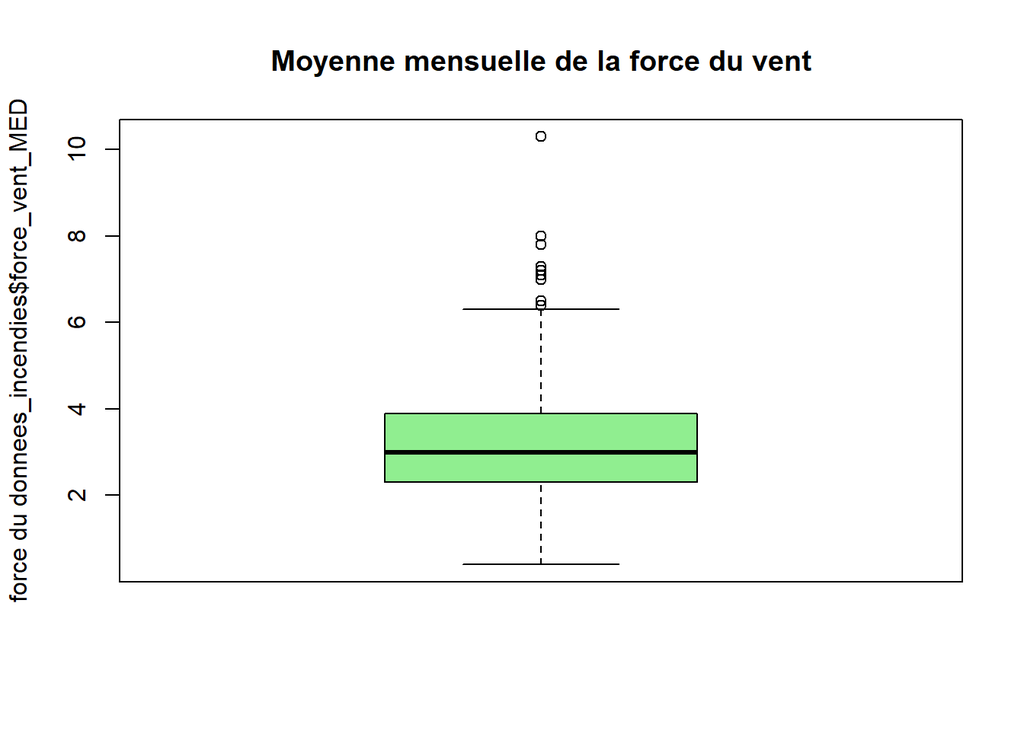

```r
boxplot(donnees_incendies$force_vent_MED,
        main = "Moyenne mensuelle de la force du vent",
        ylab = "force du donnees_incendies$force_vent_MED",
        col = "lightgreen")
```

La boîte à moustache de la variable `force_vent_MED` une repartition majoritairement égalitaire, que ce soit avec les moustaches d’une longueur approximativement équivalente (bien que plus longue pour la moustache en hauteur) et une présence de la médiane plutôt centrale, bien qu’avec un penchant vers la moitié inférieure de la boîte. Cela reprend correctement nos résultats précédents, qui indique, malgré une proximité forte entre la médiane et la moyenne, quelques exceptions de moyenne de vent fort ; provoquant un une moustache supérieure plus longue ainsi que quelques valeurs exceptionnelles marquées.

##### Histogramme

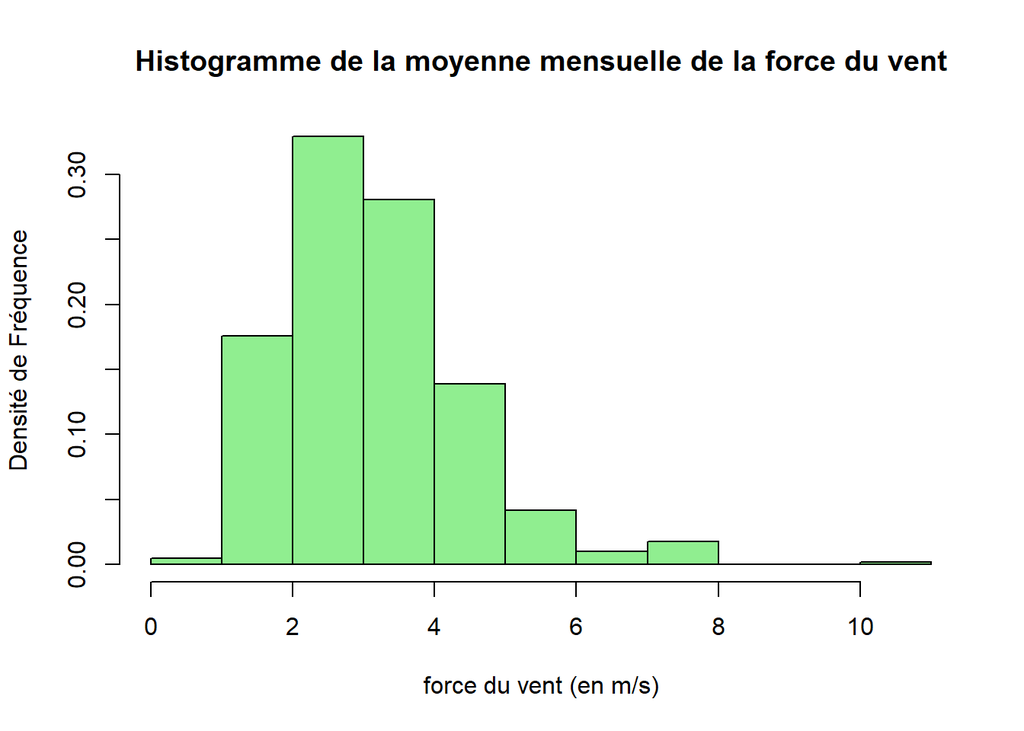

```r
hist(donnees_incendies$force_vent_MED,
     main = "Histogramme de la moyenne mensuelle de la force du vent",
     xlab = "force du vent (en m/s)",
     ylab = "Densité de Fréquence",
     probability = TRUE,
     col = "lightgreen")
```

L’histogramme de la densité de fréquence de la `force_vent_MED` des différentes communes. Nous pouvons clairement voir que la courbe à une allure de cloche, sans en avoir toutes les caractéristiques. Cela permet de constates que plus de 60% des données sont situées entre 2 et 4 m/s. Cela traduit aussi, la rareté des moyenne de vent très faible (en dessous de 1 m/s, la densité de fréquence est à environ 0,01) et de vent très fort : on se retrouve avec une densité de fréquence inférieur à 0,05 pour les moyennes de vent supérieur à 6 m/s. L’histogramme confirme la faible variabilité des moyennes de vent mensuelle sur le territoire français dans les communes observées.

#### Conclusion

L’analyse univariée de la variable `force_vent_MED` révèle une faible variabilité des moyennes de vent mensuelles, néanmoins ponctuées de quelques valeurs exceptionnelles. Cette uniformité est confirmée tant par les indicateurs statistiques (faible variance et écart-type, moyenne et médianne avec un écart peu marqué), que par les représentations graphiques (boîte à moustache et histogramme) et ceux, malgré la présence de rare mesures exceptionnelle (minimum et maximum, valeurs exceptionnelle en dehors des moustaches de la boîte à moustache). Ainsi, bien qu’il existe des exceptions, la concentration forte de moyenne de vent entre 2 m/s et 4 m/s joue un rôle déterminant dans la structure de la distribution.

### Variable nature_primaire

#### Diagramme en barres

```r
# Création d'une table des effectifs
table_nature <- table(donnees_incendies$nature_primaire)
# Calcul des fréquences relatives (en pourcentages)
pourcentages_nature <- prop.table(table_nature) * 100

# Affichage de la table des effectifs
table_nature
```

```
##
## Accidentelle Involontaire Malveillance    Naturelle
##          138          503          522           39
```

```r
# Affichage de la table des pourcentages, arrondie à deux décimales
round(pourcentages_nature, 2)
```

```
##
## Accidentelle Involontaire Malveillance    Naturelle
##        11.48        41.85        43.43         3.24
```

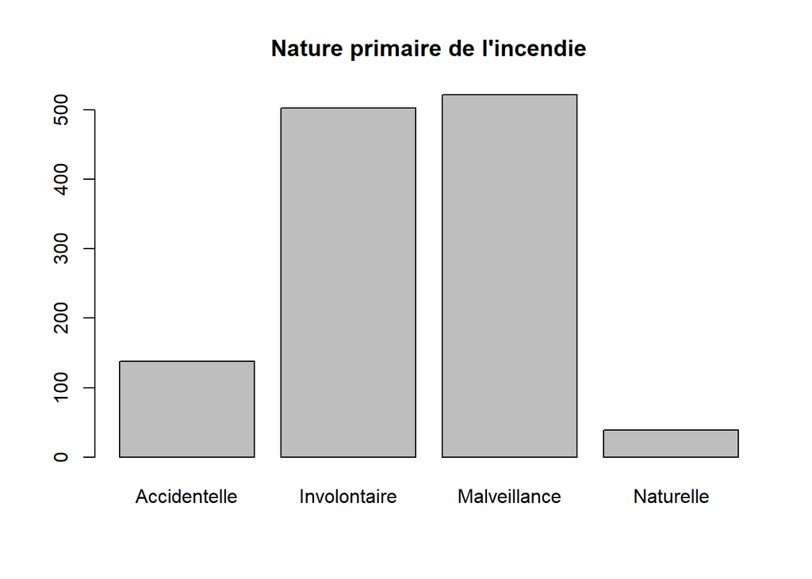

```r
barplot(table_nature,
        main = "Nature primaire de l'incendie")
```

La variable `nature_primaire` désigne la cause principale identifiée pour chaque incendie enregistré. Elle comprend 4 modalités : Accidentelle, Involontaire, Malveillance et Naturelle. La distribution des effectifs est la suivante :

- Malveillance : 522 cas
- Involontaire : 503 cas
- Accidentelle : 138 cas
- Naturelle : 39 cas

Le diagramme en barres illustre clairement cette répartition. On observe une forte prédominance des causes humaines (malveillance, involontaire, accidentelle) qui représentent près de 97 % des incendies. Les deux catégories les plus fréquentes sont :

- Les incendies attribués à la malveillance (43.43 %), ce qui reflète une part importante de feux déclenchés intentionnellement.
- Les causes involontaires (41,85 %), qui regroupent des négligences, imprudences ou comportements accidentels d’origine humaine.

Les incendies accidentels (11,5 %) complètent le groupe des causes humaines, confirmant que ce sont les activités humaines qui sont majoritairement responsables des incendies.

En revanche, les incendies d’origine naturelle sont très peu représentés (3,2 %). Cette faible proportion peut refléter un contexte géographique ou climatique peu propice aux déclenchements spontanés, ou une capacité accrue à identifier une origine humaine dans les enquêtes post-incendie.

La distribution mise en évidence par le graphique révèle donc une tendance nette vers des origines humaines, que ce soit de manière intentionnelle ou non.

#### Camemberts

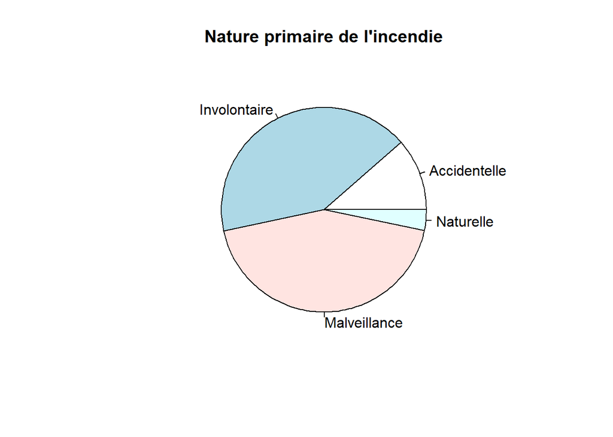

```r
pie(table(donnees_incendies$nature_primaire),
    main = "Nature primaire de l'incendie")
```

Le diagramme en camembert met en évidence une nette prédominance des incendies d’origine involontaire et malveillante. Les causes accidentelles et naturelles, bien que présentes, occupent une part beaucoup plus réduite. Cette représentation visuelle montre que la majorité des incendies sont liés à des actions humaines, qu’elles soient délibérées (comme la malveillance) ou non. Il est néanmoins important de souligner que la plupart des incendies n’étaient pas provoqués de manière intentionnelle : ils relèvent majoritairement de situations non prévues ou non contrôlées, incluant les causes involontaires, accidentelles ou naturelles.

#### Conclusion

L’analyse de la variable `nature_primaire` révèle une nette prédominance des causes humaines dans le déclenchement des incendies, représentant près de 97 % des cas. Les incendies liés à la malveillance (43,4 %) et aux causes involontaires (41,9 %) sont les plus fréquents, suivis des causes accidentelles (11,5 %). En comparaison, les incendies d’origine naturelle restent très marginaux (3,2 %), ce qui peut s’expliquer par un contexte peu favorable aux feux spontanés ou par une meilleure traçabilité des origines humaines.

### Variable nature_secondaire

Cette analyse porte uniquement sur les incendies classés comme **involontaires**. La variable `nature_secondaire` précise leur origine en distinguant deux situations : les incendies liés à des **travaux** et ceux liés à des **particuliers**.

```r
table(donnees_incendies$nature_secondaire)
```

```
##
## particulier     travaux
##         221         282
```

Parmi les incendies involontaires, les données montrent une légère prédominance des cas liés à des travaux (282) par rapport à ceux provoqués par des particuliers (221). Cela suggère que, dans ce type d’incendie, les activités professionnelles ou techniques constituent une source de risque un peu plus fréquente que les usages domestiques. L’écart reste toutefois modéré, ce qui indique que les deux origines doivent faire l’objet d’une attention comparable en matière de prévention.

#### Diagramme en barres

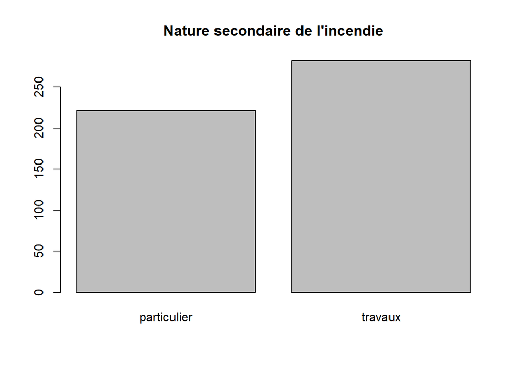

```r
barplot(table(donnees_incendies$nature_secondaire),
        main = "Nature secondaire de l'incendie")
```

À partir du diagramme en barres, on observe que parmi les incendies d’origine involontaire, ceux liés aux travaux sont légèrement plus fréquents que ceux causés par des particuliers. La répartition reste néanmoins assez équilibrée entre les deux catégories.

#### Camemberts

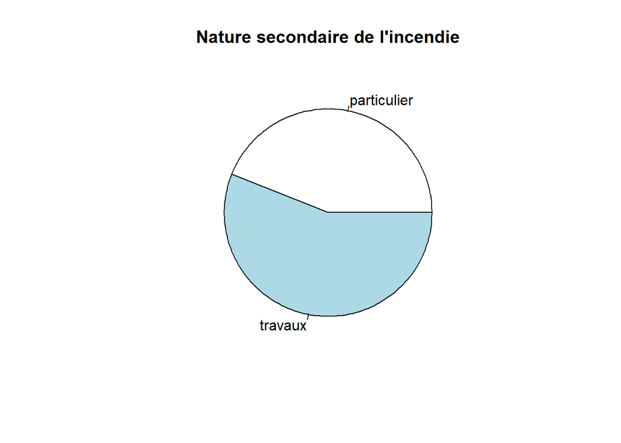

```r
pie(table(donnees_incendies$nature_secondaire),
    main = "Nature secondaire de l'incendie")
```

Le diagramme en camembert permet de visualiser la répartition des incendies involontaires selon leur nature secondaire. Comme dit précédemment, on observe une légère prédominance des incendies liés aux travaux par rapport à ceux causés par des particuliers, bien que les proportions restent relativement proches.

#### Conclusion

L’analyse univariée de la variable nature secondaire de l’incendie, restreinte aux cas d’origine involontaire, montre une légère prédominance des incendies liés aux travaux par rapport à ceux causés par des particuliers. Cette tendance, visible sur les deux représentations graphiques, suggère que les activités professionnelles ou techniques sont un facteur un peu plus fréquent dans ce type d’incendie.

### Variable Mois

#### Diagramme en barres

```r
ordre_mois <- c("Jan", "Feb", "Mar", "Apr", "May", "Jun",
                "Jul", "Aug", "Sep", "Oct", "Nov", "Dec")

donnees_incendies$mois <- factor(donnees_incendies$mois, levels = ordre_mois)

table(donnees_incendies$mois)
```

```
##
## Jan Feb Mar Apr May Jun Jul Aug Sep Oct Nov Dec
##  38  99 144  80  20 101 266 242 137  52  14   9
```

Afin de représenter correctement la répartition mensuelle des incendies, il est nécessaire de s’assurer que les mois soient ordonnés de manière chronologique (de janvier à décembre). Ainsi on a commencé par définir un vecteur `ordre_mois` contenant les mois dans l’ordre souhaité puis on a transformé en facteur la variable `mois` en ordonnant les mois à l’aide de `ordre_mois`.

L’analyse de la fréquence des incendies par mois met en évidence une forte saisonnalité. On observe une forte concentration des incendies pendant l’été, en particulier aux mois de juillet (266 incendies) et août (242 incendies), ce qui est cohérent avec les conditions climatiques en France à cette période. Les mois de juin (101 incendies) et septembre (137 incendies) présentent également des niveaux relativement élevés, bien que moindres comparés aux mois de juillet et aout.

Les mois d’hiver enregistrent le nombre d’incendies les plus faibles, notamment en novembre (14 incendies) et décembre (9 incendies), période où les conditions météorologiques (pluie, températures basses…) limitent fortement le risque d’incendies.

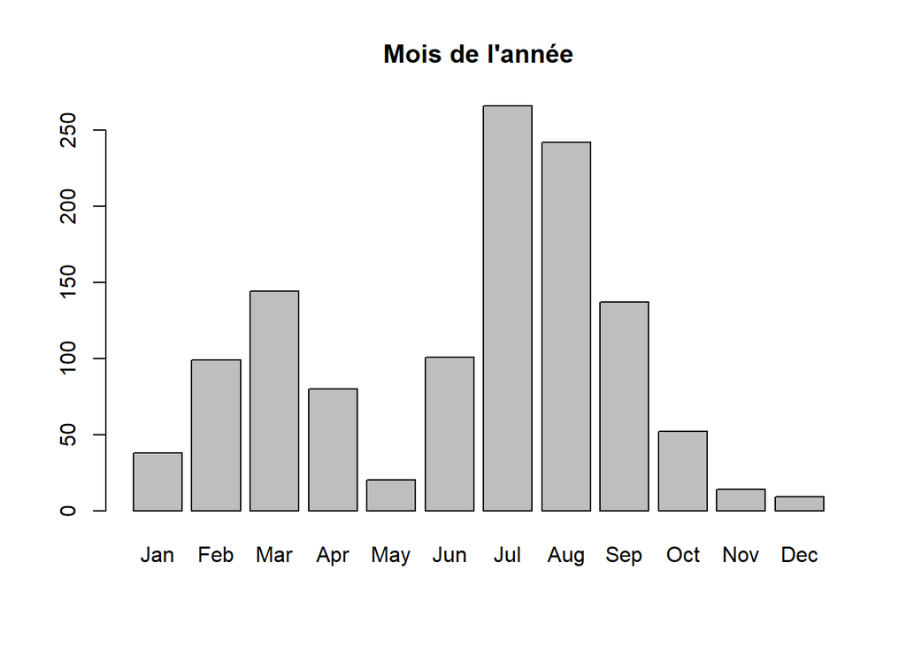

```r
barplot(table(donnees_incendies$mois),
        main = "Mois de l'année")
```

Le diagramme en barres présente la répartition mensuelle des incendies sur l’ensemble de l’année. Les données mettent en évidence deux périodes principales d’activité élevée.

La première période s’étend de février à avril, avec 99 incendies en février, 144 en mars et 80 en avril. Cette phase est suivie d’une baisse marquée en mai, où seuls 20 incendies sont enregistrés.

La seconde période débute en juin (101 incendies) et se prolonge jusqu’en septembre (137 incendies), avec un pic en juillet (266 incendies) et un niveau également très élevé en août (242 incendies). Cette période regroupe les valeurs les plus élevées de l’année.

En dehors de ces deux périodes, le nombre d’incendies reste nettement plus faible, notamment en novembre (14) et décembre (9).

Ainsi, la répartition mensuelle des incendies présente une structure marquée, avec deux phases où leur nombre est particulièrement élevé, séparées par une baisse nette au mois de mai.

#### Camemberts

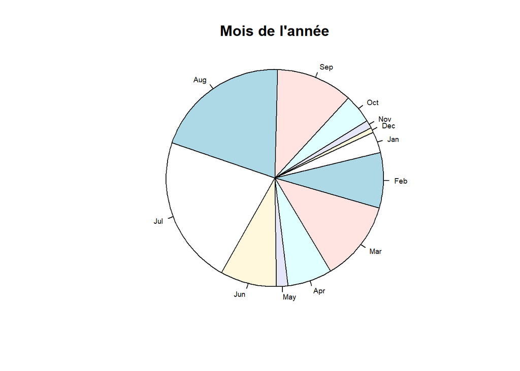

```r
pie(table(donnees_incendies$mois),
    main = "Mois de l'année",
    clockwise = TRUE,
    init.angle = 25,
    cex = 0.6,
    radius = 1)
```

Le diagramme circulaire met en évidence une forte saisonnalité des incendies, avec une prédominance nette durant l’été : juillet et août représentent les plus grandes parts, correspondant aux pics d’incendies annuels. Une autre période d’activité importante est visible en fin d’hiver et au printemps, notamment en février et mars. Le mois de mai marque une baisse nette entre ces deux phases. À l’inverse, les mois d’automne et d’hiver, en particulier novembre et décembre, enregistrent les parts les plus faibles, traduisant une faible occurrence des incendies en période froide.

#### Conclusion

En conclusion, l’analyse de la répartition mensuelle des incendies révèle une dynamique clairement saisonnière, avec deux périodes d’activité marquée : une première au printemps (février à avril) et une seconde plus intense en été (juin à septembre), dominée par les mois de juillet et août. Cette distribution est étroitement liée aux conditions climatiques, favorisant la survenue des incendies durant les périodes chaudes et sèches. À l’inverse, les mois d’hiver affichent une activité minimale, soulignant l’influence déterminante de la saison sur la fréquence des incendies.

### Variable Année

#### Indicateurs numériques

**Calcul de la moyenne**

```r
mean(donnees_incendies$annee, na.rm = TRUE)
```

```
## [1] 2017.649
```

**Calcul de l’écart-type**

```r
sd(donnees_incendies$annee, na.rm = TRUE)
```

```
## [1] 3.339497
```

**Calcul de la variance**

```r
var(donnees_incendies$annee, na.rm = TRUE)
```

```
## [1] 11.15224
```

**Plus petite valeur**

```r
min(donnees_incendies$annee, na.rm = TRUE)
```

```
## [1] 2012
```

**Plus grande valeur**

```r
max(donnees_incendies$annee, na.rm = TRUE)
```

```
## [1] 2022
```

**Vecteur contenant le minimum et le maximum**

```r
range(donnees_incendies$annee, na.rm = TRUE)
```

```
## [1] 2012 2022
```

**Calcul de la médiane**

```r
median(donnees_incendies$annee, na.rm = TRUE)
```

```
## [1] 2017
```

**Résumé de la variable surface_parcourue_m2**

```r
summary(donnees_incendies$annee)
```

```
##    Min. 1st Qu.  Median    Mean 3rd Qu.    Max.
##    2012    2015    2017    2018    2021    2022
```

La moyenne (2018) et la moyenne (2017) sont proches, on peut donc suppposer que la distribution est plutôt symétrique, sans forte asymétrie. Les 1er et 3ème quartiles (2015,2021) indiquent que la moitié des incendies observés ont eu lieu entre 2015 et 2021, ce qui peut refléter ou une meilleure récolte des données ou une intensification du phénomène dans cette période.

L’écart-type de 3.34 et la variance modérée (11.15) indiquent une dispersion raisonnable autour de la moyenne. La plage temporelle (2012-2022) est de 11 ans.

#### Représentation graphique

##### Boîte-à-moustache

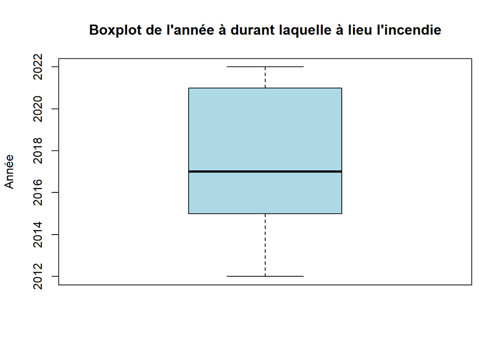

```r
boxplot(donnees_incendies$annee,
        main = "Boxplot de l'année à durant laquelle à lieu l'incendie",
        ylab = "Année",
        col = "lightblue")
```

##### Diagramme en bâtons

On détermine les effectifs pour chaque modalité distincte de la variable `annee` avant de réaliser le diagramme en bâtons.

```r
table(donnees_incendies$annee)
```

```
##
## 2012 2013 2014 2015 2016 2017 2018 2019 2020 2021 2022
##  122   59   65  107  104  146   42  135  102   79  241
```

Les effectifs d’incendies fluctuent beaucoup d’une année à l’autre. Par exemple, 2018 se distingue par un nombre particulièrement bas d’incendies (42), ce qui semble être une anomalie dans le contexte général. En revanche, 2022 affiche un nombre très élevé (241), ce qui suggère soit une intensification des incendies, soit un meilleur enregistrement des événements.

- Une augmentation réelle des incendies, possiblement due à des facteurs environnementaux comme le changement climatique, des sécheresses ou des conditions météorologiques extrêmes.
- Un meilleur suivi et une collecte de données plus précise sur les incendies dans ces dernières années.

Avant 2018, les nombres d’incendies sont relativement stables, oscillant entre 59 et 146 incendies par an, sans grandes variations. On note toutefois une légère tendance à la hausse, particulièrement après 2015 (107 incendies), et une augmentation marquée en 2017 (146 incendies). Cette tendance pourrait être liée à une meilleure couverture de suivi des incendies ou à des changements dans les pratiques de gestion des incendies.

L’année 2018 se distingue clairement par une chute drastique des incendies (42). Ce creux pourrait être dû à une collecte de données moins exhaustive ou à d’autres facteurs comme une réduction des conditions propices aux incendies (par exemple, un hiver plus humide ou moins de vagues de chaleur). Cela pourrait aussi indiquer des problèmes dans la collecte de données cette année-là.

L’année 2022 affiche une hausse importante du nombre d’incendies (241), bien au-delà des autres années. Cette hausse pourrait être liée à des événements exceptionnels (grandes sécheresses, vagues de chaleur, incendies de grande ampleur).

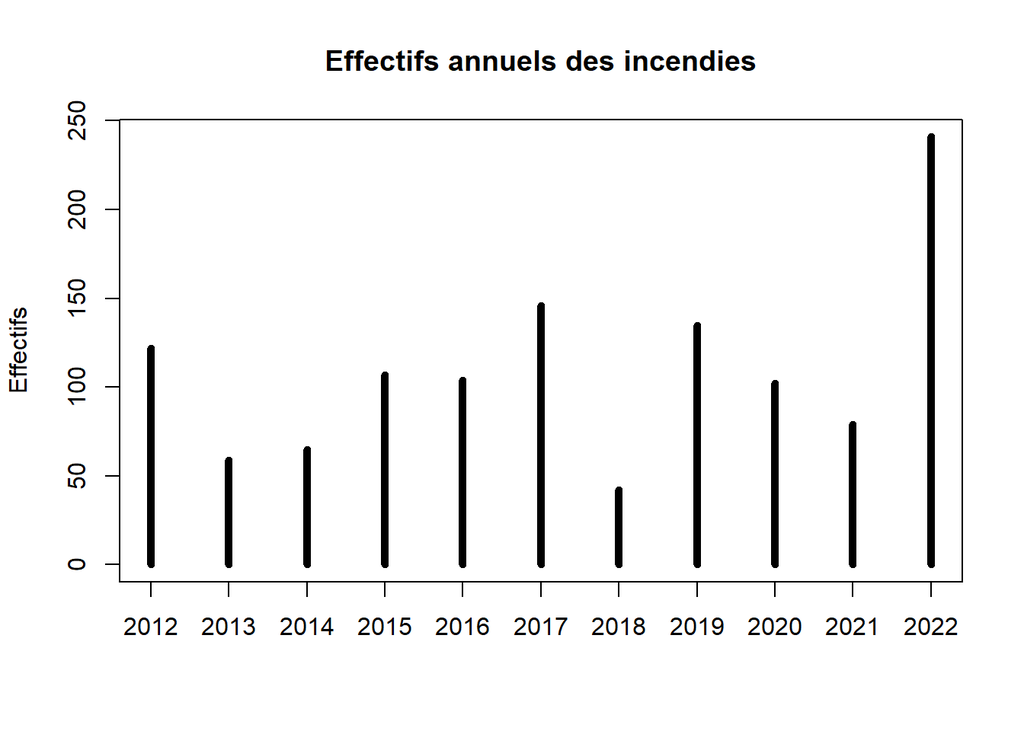

```r
plot(table(donnees_incendies$annee),
     main = "Effectifs annuels des incendies",
     ylab = "Effectifs",
     lwd = 5)
```

Il n’y a pas de tendance claire à la hausse ou à la baisse sur la période observée. Les données montrent plutôt des fluctuations importantes d’une année à l’autre.

#### Conclusion

L’analyse des effectifs annuels des incendies entre 2012 et 2022 met en lumière une forte variabilité d’une année à l’autre, sans tendance claire à la hausse ou à la baisse. Certaines années, comme 2022, se distinguent par un nombre exceptionnellement élevé d’incendies, tandis que d’autres, comme 2018, enregistrent des valeurs particulièrement basses. Ces fluctuations peuvent être attribuées à des facteurs environnementaux, tels que des conditions météorologiques extrêmes, ou à des améliorations dans les méthodes de collecte et de suivi des données.

### Variable altitude_med

#### Indicateurs numériques

**Calcul de la moyenne**

```r
mean(donnees_incendies$altitude_med, na.rm = TRUE)
```

```
## [1] 357.6664
```

**Calcul de l’écart-type**

```r
sd(donnees_incendies$altitude_med, na.rm = TRUE)
```

```
## [1] 378.1994
```

**Calcul de la variance**

```r
var(donnees_incendies$altitude_med, na.rm = TRUE)
```

```
## [1] 143034.8
```

**Plus petite valeur**

```r
min(donnees_incendies$altitude_med, na.rm = TRUE)
```

```
## [1] 0
```

**Plus grande valeur**

```r
max(donnees_incendies$altitude_med, na.rm = TRUE)
```

```
## [1] 2100
```

**Vecteur contenant le minimum et le maximum**

```r
range(donnees_incendies$altitude_med, na.rm = TRUE)
```

```
## [1]    0 2100
```

**Calcul de la médiane**

```r
median(donnees_incendies$altitude_med, na.rm = TRUE)
```

```
## [1] 200
```

```r
summary(donnees_incendies$altitude_med)
```

```
##    Min. 1st Qu.  Median    Mean 3rd Qu.    Max.
##     0.0    72.0   200.0   357.7   554.5  2100.0
```

La dispersion de l’altitude des communes touchées par des incendies est élevée, avec un écart-type de **378.2 m**. Cela reflète une variabilité forte entre les communes. La variance, estimée à **143 034.8 m²**, confirme cette dispersion.

Concernant les valeurs extrêmes, les altitudes des communes touchées par des incendies s’étendent de **0 m** à **2 100 m**, ce qui montre une forte amplitude altimétrique entre les communes les plus basses et les plus hautes touchées par des incendies.

Le premier quartile se situe à **72 m** et le troisième quartile à **554.5 m**, ce qui signifie que la moitié des communes touchées par des incendies se situent à une altitude comprise entre ces deux bornes.

#### Représentation graphique

##### Boîte-à-moustache

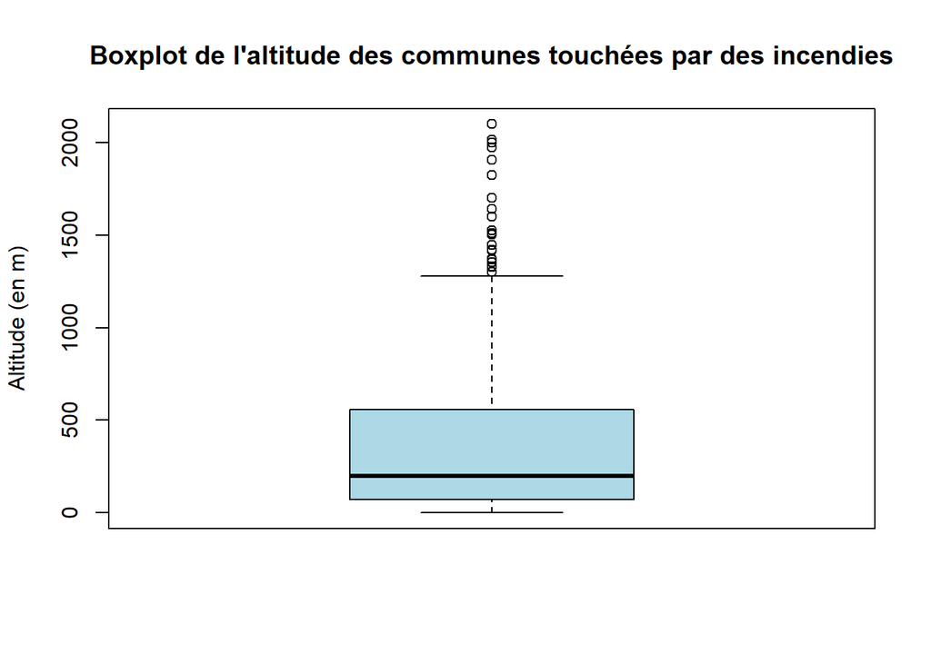

```r
boxplot(donnees_incendies$altitude_med,
        main = "Boxplot de l'altitude des communes touchées par des incendies",
        ylab = "Altitude (en m)",
        col = "lightblue")
```

Le boxplot de l’altitude des communes touchées par des incendies montre une distribution asymétrique à droite, avec des valeurs extrêmes marquées au-dessus des moustaches. Cela indique une répartition des altitudes avec une concentration de valeurs basses à modérées, mais aussi des altitudes exceptionnellement élevées.

Cette distribution suggère que, bien que la plupart des communes se trouvent à des altitudes relativement basses, il existe des cas particuliers à des altitudes très élevées. Cela pourrait refléter des caractéristiques géographiques spécifiques, comme la présence de zones montagneuses.

##### Histogramme

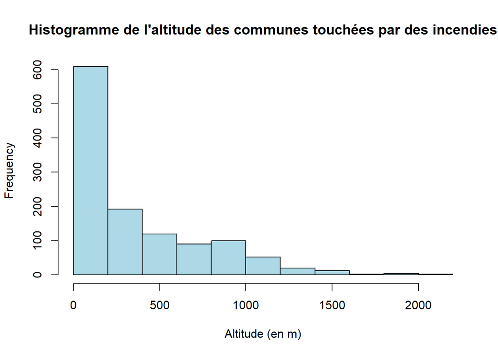

```r
hist(donnees_incendies$altitude_med,
     main = "Histogramme de l'altitude des communes touchées par des incendies",
     xlab = "Altitude (en m)",
     col = "lightblue")
```

Cet histogramme montre la distribution des altitudes des communes touchées par des incendies, avec une asymétrie à droite. La majorité des communes se situent à des altitudes basses (0 - 500 m), avec une fréquence décroissante à mesure que l’altitude augmente.

- Altitudes basses (0 - 500 m) : Plus de 600 communes, indiquant une forte concentration d’incendies à ces altitudes.
- Altitudes modérées (500 - 1 000 m) : Environ 200 à 300 communes, montrant une diminution de la fréquence.
- Altitudes élevées (1 000 - 2 000 m) : Très peu de communes, indiquant que les incendies en haute altitude sont rares.

La distribution est asymétrique à droite, avec une grande variabilité des altitudes (0 m à plus de 2000 m). Cela suggère que les incendies sont plus fréquents à basse altitude, mais peuvent se produire dans une large gamme de conditions géographiques.

### Variable NBJRR1_MED

#### Indicateurs numériques

**Calcul de la moyenne**

```r
mean(donnees_incendies$NBJRR1_MED, na.rm = TRUE)
```

```
## [1] 6.65183
```

**Calcul de l’écart-type**

```r
sd(donnees_incendies$NBJRR1_MED, na.rm = TRUE)
```

```
## [1] 2.464746
```

**Calcul de la variance**

```r
var(donnees_incendies$NBJRR1_MED, na.rm = TRUE)
```

```
## [1] 6.074972
```

**Plus petite valeur**

```r
min(donnees_incendies$NBJRR1_MED, na.rm = TRUE)
```

```
## [1] 2
```

**Plus grande valeur**

```r
max(donnees_incendies$NBJRR1_MED, na.rm = TRUE)
```

```
## [1] 18
```

**Vecteur contenant le minimum et le maximum**

```r
range(donnees_incendies$NBJRR1_MED, na.rm = TRUE)
```

```
## [1]  2 18
```

**Calcul de la médiane**

```r
median(donnees_incendies$NBJRR1_MED, na.rm = TRUE)
```

```
## [1] 6
```

```r
summary(donnees_incendies$NBJRR1_MED)
```

```
##    Min. 1st Qu.  Median    Mean 3rd Qu.    Max.
##   2.000   5.000   6.000   6.652   8.375  18.000
```

L’analyse des indicateurs numériques de la variable `NBJRR1_MED` montre que le nombre de jours moyen avec des précipitations supérieures ou égales à 1 mm est de **6.652** et la médiane est de **6 jours**. La moyenne étant proche de la médiane, cela indique que la distribution relativement symétrique.

La dispersion du nombre de jours avec des précipitations supérieures ou égales à 1 mm est faible, avec un écart-type de **2.46 jours**. Cela reflète une faible variabilité entre les communes. La variance, estimée à **6.074972**, confirme cette dispersion.

Concernant les valeurs extrêmes, le nombre de jours avec des précipitations supérieures ou égales à 1 mm s’étend **de 2 à 18 jours**, ce qui montre une forte amplitude entre les communes les plus moins et les plus pluvieuses touchées par des incendies.

Le premier quartile se situe à **5 jours** et le troisième quartile à **8.375**, ce qui signifie que la moitié des communes touchées par des incendies ont un nombre de jours avec des précipitations supérieures ou égales à mm situé entre ces deux bornes.

#### Représentation graphique

##### Boîte-à-moustache

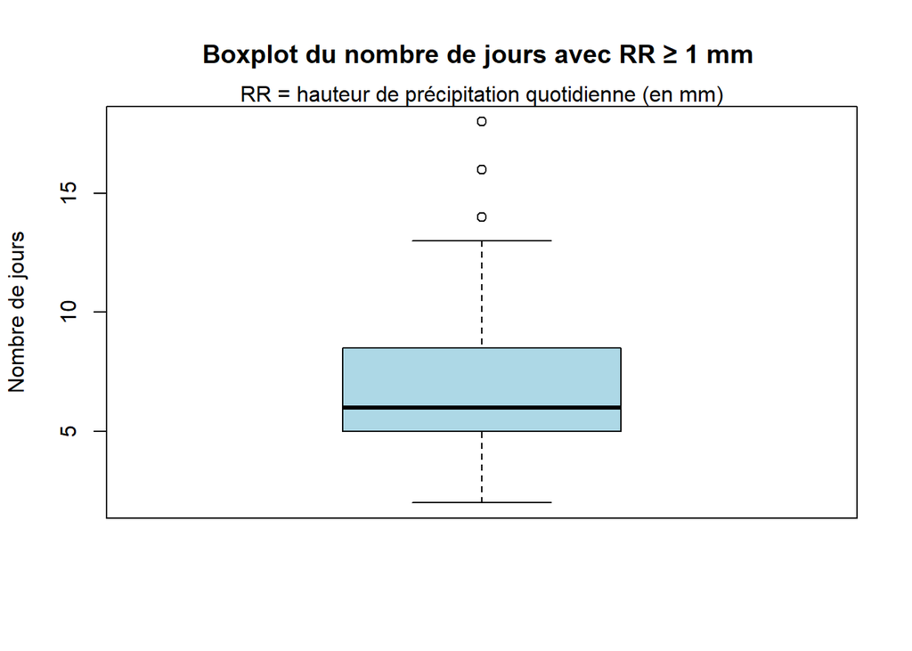

```r
boxplot(donnees_incendies$NBJRR1_MED,
        main = "Boxplot du nombre de jours avec RR ≥ 1 mm ",
        ylab = "Nombre de jours",
        col = "lightblue")
mtext("RR = hauteur de précipitation quotidienne (en mm)")
```

Le boxplot du nombre de jours avec une hauteur de précipitation quotidienne supérieure ou égale à 1 mm (`NBJRR1_MED`) montre une distribution légèrement asymétrique à droite, avec quelques valeurs extrêmes au-dessus des moustaches. Cela indique que, bien que la majorité des communes touchées par des incendies connaissent un nombre modéré de jours de pluie, certaines présentent un nombre très élevé de jours pluvieux.

Cette distribution suggère que, bien que la pluviométrie reste généralement modérée pour la majorité des communes, certaines zones présentent un niveau de précipitations bien plus élevé, ce qui pourrait être lié à des facteurs géographiques comme la proximité de reliefs, ou à des microclimats particuliers.

##### Diagramme en bâtons

On détermine les effectifs pour chaque modalité distincte de la variable `NBJRR1_MED` avant de réaliser le diagramme en bâtons.

```r
table(donnees_incendies$NBJRR1_MED)
```

```
##
##    2  2.5    3  3.5    4  4.5    5  5.5    6  6.5    7  7.5    8  8.5    9  9.5
##    6    1   51    4  169    9  257    9  171    9  107   10   98    1   91    5
##   10 10.5   11 11.5   12   13   14   16   18
##  100    3   62    8   23    4    2    1    1
```

La table des effectifs de la variable `NBJRR1_MED`, représentant la médiane mensuelle du nombre de jours avec des précipitations ≥ 1 mm sur la période 1950–2022, montre une concentration nette des communes entre 4 et 8 jours par mois, avec un pic à 5 jours. Cela indique que, dans la majorité des cas, les communes touchées par des incendies connaissent 6 jours ou moins de pluie par mois, en médiane. Les valeurs extrêmes au-delà de 13 jours sont rares et traduisent des situations particulières, liées probablement à des conditions géographiques plus humides.

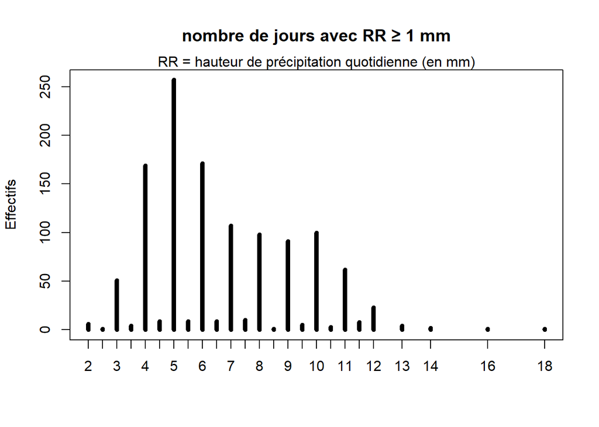

```r
plot(table(donnees_incendies$NBJRR1_MED),
     main = "nombre de jours avec RR ≥ 1 mm",
     ylab = "Effectifs",
     lwd = 5)
mtext("RR = hauteur de précipitation quotidienne (en mm)")
```

Le diagramme en barres montre une distribution asymétrique à droite, avec une forte concentration des communes connaissant 5 à 6 jours de précipitations mensuels. Le pic se situe à 5 jours, suivi de valeurs décroissantes au-delà de 7 jours, traduisant une diminution progressive du nombre de communes plus pluvieuses.

Les effectifs deviennent très faibles au-delà de 12 jours, et quelques valeurs isolées apparaissent jusqu’à 18 jours, indiquant des cas rares de mois particulièrement pluvieux dans certaines communes.

#### Conclusion

En conclusion, l’analyse de la variable `NBJRR1_MED` met en évidence une pluviométrie mensuelle généralement faible à modérée dans les communes touchées par des incendies, avec une médiane de 6 jours de pluie par mois. La distribution est légèrement asymétrique à droite, montrant que la majorité des communes reçoivent entre 4 et 8 jours de pluie, tandis que quelques cas isolés présentent une pluviométrie bien plus élevée. Cette variabilité limitée suggère que, dans l’ensemble, les zones concernées sont relativement sèches, ce qui pourrait contribuer à leur vulnérabilité aux incendies, notamment en l’absence de pluie prolongée.

## Identification de problématiques statistiques

Dans le cadre de notre projet d’analyse des incendies, plusieurs problématiques statistiques ont été retenues afin d’approfondir notre compréhension des phénomènes observés :

### Influence de la force du vent

**Problématique :**  
Dans quelle mesure la force moyenne du vent influence-t-elle l’ampleur des incendies en termes de surface parcourue ?

**Objectif :**  
Étudier la relation entre la force moyenne du vent (`force_vent_MED`) et la surface parcourue par les incendies (`surface_parcouru_m2`), pour voir si des vents plus forts sont associés à des incendies plus graves.

### Impact de la température maximale

**Problématique :**  
Existe-t-il une relation entre la température maximale moyenne et la surface brûlée lors des incendies ?

**Objectif :**  
Analyser si des températures maximales élevées (`Tmax_MED`) augmentent la gravité des incendies en termes de surface brûlée.

### Influence du type d’incendie

**Problématique :**  
La nature primaire des incendies a-t-elle un effet significatif sur la surface qu’ils parcourent ?

**Objectif :**  
Comparer les surfaces parcourues selon la nature primaire des incendies pour identifier les types les plus destructeurs.

### Effet de la période de l’année

**Problématique :**  
Certaines périodes de l’année sont-elles associées à des incendies de plus grande ampleur en termes de surface affectée ?

**Objectif :**  
Vérifier si certaines périodes de l’année (`mois`) sont plus propices à de plus grands incendies.

### Influence de la latitude des communes

**Problématique :**  
La position géographique des communes, notamment leur latitude, a-t-elle un impact sur la gravité des incendies mesurée en surface parcourue ?

**Objectif :**  
Étudier si la position géographique des communes (via leur `latitude`) influence l’ampleur des incendies.

### Résumé des problématiques et des variables concernées

| Thématique | Variables principales |
| --- | --- |
| Force du vent | `force_vent_MED`, `surface_parcouru_m2` |
| Température maximale | `Tmax_MED`, `surface_parcouru_m2` |
| Type d’incendie | `nature_primaire`, `surface_parcouru_m2` |
| Latitude | `latitude`, `surface_parcouru_m2` |
| Période de l’année | `mois`, `surface_parcouru_m2` |

## Réponses aux problématiques identifiées

### Dans quelle mesure la force moyenne du vent influence-t-elle l’ampleur des incendies en termes de surface parcourue ?

#### Chargement des données

```r
vent_surface <- read.csv("../Exports/surface_vs_force_vent.csv",
                         encoding = "UTF-8",
                         stringsAsFactors = TRUE)
surface_log <- log(vent_surface$surface_parcouru_m2)
vent <- vent_surface$force_vent_MED
```

On utilise l’objet surface en log pour une meilleure lisibilité.

#### Analyse Graphique

##### **Nuage de points**

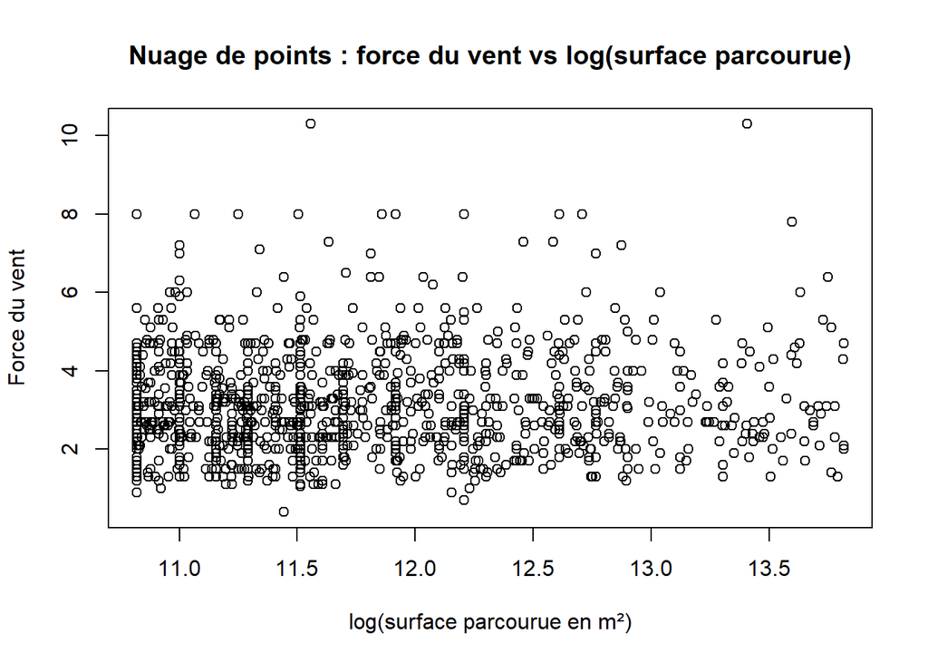

```r
plot(surface_log, vent, xlab = "log(surface parcourue en m²)", ylab = "Force du vent", main = "Nuage de points : force du vent vs log(surface parcourue)")
```

Etant donné que aucune droite ne se démarque du nuage de points, on va voir l’étude d’une manière différente. En effet, la variable de la force du vent se mesure sur une moyenne du vent durant le mois et non sur la force du vent durant l’incendie : cela conduit à une étude qui n’a pas vraiment de sens.

Ainsi on va faire transformer la variable force_vent_MED en une variable catégorielle des vents supérieurs (zone venteuse) et inférieurs (zone non venteuse) à 5 m/s en moyenne sur le mois.

```r
vent_5_metre_seconde <- ifelse(vent_surface$force_vent_MED > 5, "zone venteuse", "zone non venteuse")
```

On transforme en facteur `vent_5_metre_seconde`.

```r
VENTCATSURFACELOG = data.frame(surface_log, vent_5_metre_seconde)
```

##### **Boxplot**

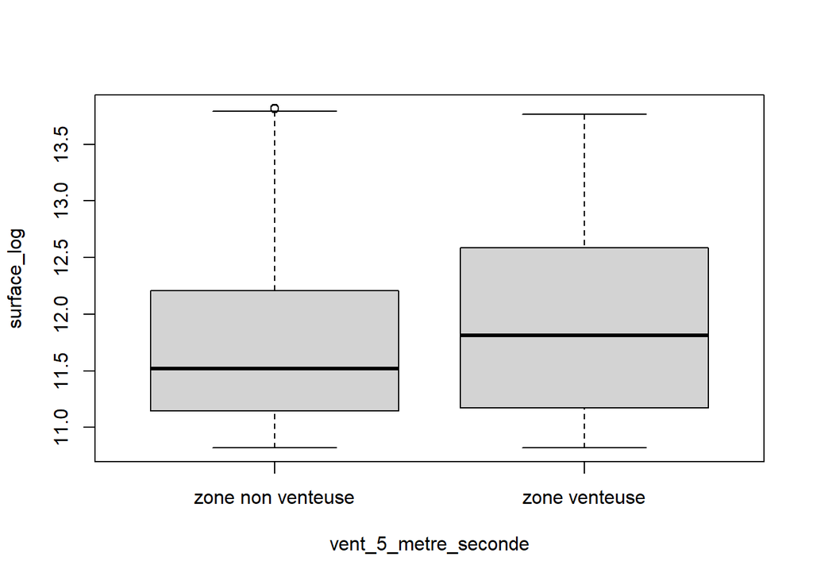

```r
boxplot(surface_log ~ vent_5_metre_seconde, data = VENTCATSURFACELOG)
```

En comparant les deux boîtes à moustache, on constate que les boîtes à moustache se retrouvent avec leurs moustaches s’arrêtant aux même niveaux. Néanmoins, on peut voir que la médiane et le troisième quartile de la boîte à moustache de la zone venteuse s’arrête à des valeurs plus élevées que la boîte à moustache de la zone non venteuse. Cela peut laisser à penser que les deux variables sont dépendantes.

##### **Histogramme**

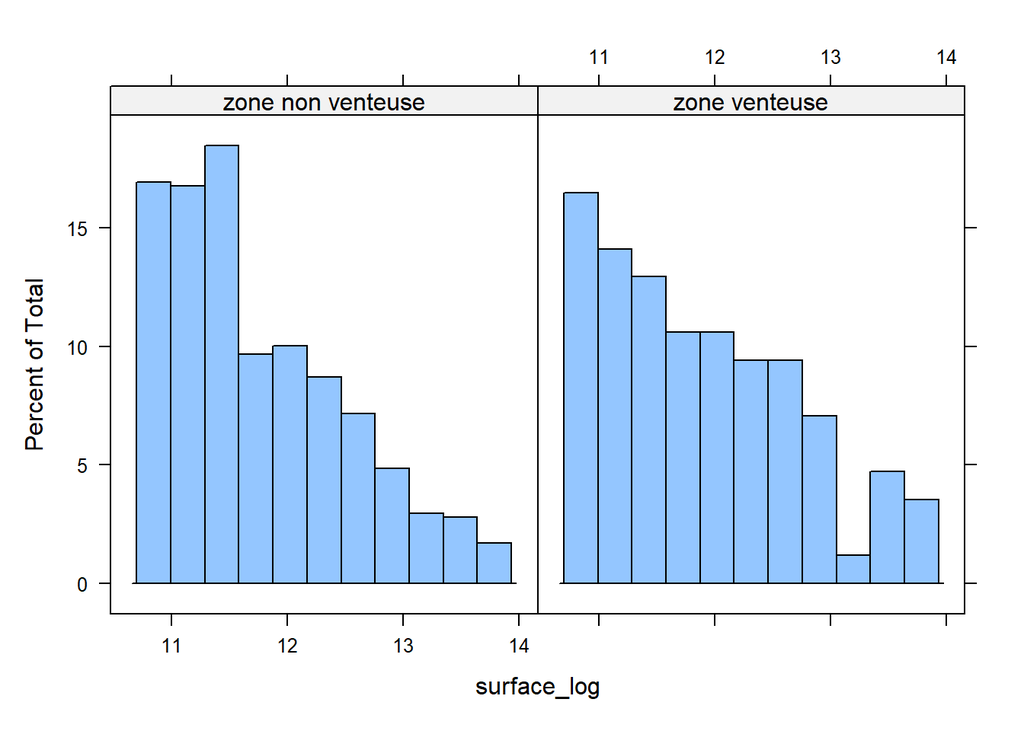

```r
library("lattice")
histogram(~ surface_log | vent_5_metre_seconde, data = VENTCATSURFACELOG)
```

On constate ici le même phénomène : les incendies se propagent davantage dans les zones venteuses.

#### Analyse Statistique : Rapport de corrélation

```r
res_lm = lm(surface_log~vent_5_metre_seconde, data = VENTCATSURFACELOG)
rap_cor = sqrt(summary(res_lm)$r.squared)
rap_cor
```

```
## [1] 0.05546887
```

Le rapport de corrélation est très faible car proche de 0. Il se situe entre 0.0 et 0.1, ce qui indique “aucune corrélation”. Il n’y a donc pas de corrélation entre le fait qu’un incendie se déclenche dans une zone venteuse et le fait qu’il est une grande étendue.

### Existe-t-il une relation entre la température maximale moyenne et la surface brûlée lors des incendies ?

#### Chargement des données

```r
surface_tmax <- read.csv("../Exports/surface_vs_Tmax.csv",
                         encoding = "UTF-8",
                         stringsAsFactors=TRUE)

surface_tmax_log <- data.frame(
  logSurface = log(surface_tmax$surface_parcouru_m2),
  tmax = surface_tmax$Tmax_MED
)
```

#### Analyse graphique

##### **Nuage de points**

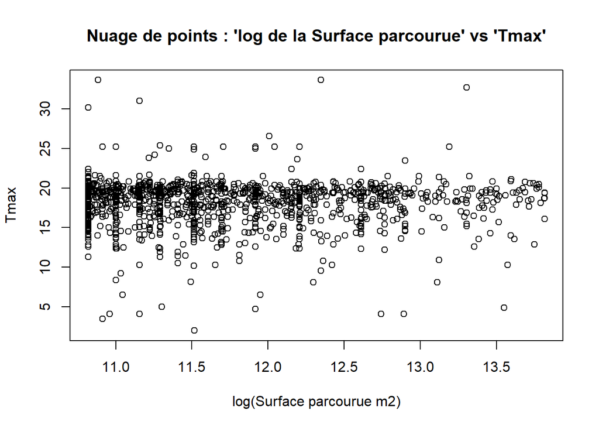

```r
plot(surface_tmax_log$logSurface, surface_tmax_log$tmax,
     xlab = "log(Surface parcourue m2)",
     ylab = "Tmax",
     main = "Nuage de points : 'log de la Surface parcourue' vs 'Tmax'"
)
```

Le nuage de points représentant la relation entre la température maximale moyenne mensuelle et le logarithme de la surface parcourue par les incendies met en évidence une forte dispersion des valeurs de Tmax pour chaque niveau de surface. Cette dispersion important suggère qu’il n’existe pas de relation claire ou significative entre ces deux variables. La densité des points est globalement concentrée autour de valeurs moyennes de Tmax (environ 18 à 21°C), indépendamment de la surface parcourue.

##### **Droite de régression**

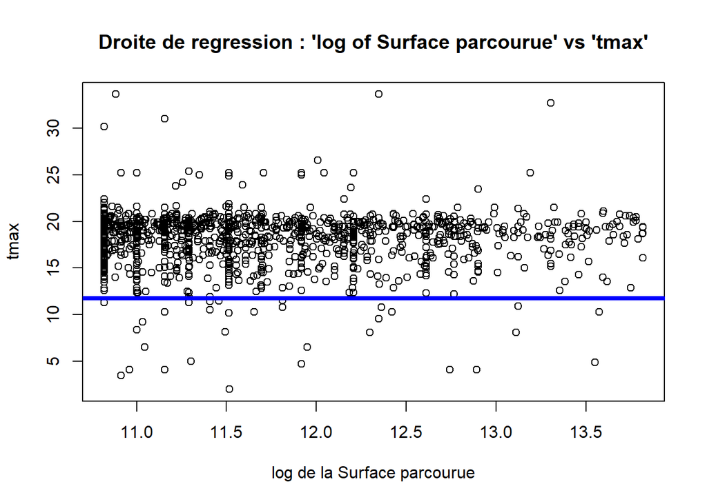

```r
reglin1 = lm(logSurface ~ tmax, surface_tmax_log)
plot(surface_tmax_log$logSurface, surface_tmax_log$tmax,
     xlab = "log de la Surface parcourue",
     ylab = "tmax",
     main = "Droite de regression : 'log of Surface parcourue' vs 'tmax'"
)
abline(reglin1, col = "blue", lwd = 4)
```

#### Analyse statistique : Coefficient de corrélation linéaire

```r
cor(surface_tmax_log$tmax,
    surface_tmax_log$logSurface)
```

```
## [1] -0.002405495
```

Le coefficient de corrélation linéaire entre la température maximale moyenne mensuelle et le logarithme de la surface parcourue est de **-0,002**. Cette valeur, quasiment nulle, indique qu’il n’existe pas de relation linéaire significative entre ces deux variables. Ainsi, la température maximale moyenne mensuelle n’a pas d’effet sur la gravité des incendies mesurée par la surface brûlée.

#### Conclusion

L’ensemble des analyses graphiques et numériques permet de conclure que la température maximale moyenne mensuelle n’influence pas significativement la surface parcourue par les incendies en France métropolitaine. Nous ne rejetons pas l’hypothèse nulle (H₀) : Il n’existe aucune relation entre la température maximale moyenne mensuelle et la surface parcourue par les incendies.

### La nature primaire des incendies a-t-elle un effet significatif sur la surface qu’ils parcourent ?

#### Chargement des données

```r
surface_nature <- read.csv("../Exports/surface_vs_nature_primaire.csv",
                              encoding = "UTF-8",
                              stringsAsFactors=TRUE)

SURFACENATURELOG <- data.frame(surface_nature$nature_primaire, log(surface_nature$surface_parcourue_m2))
colnames(SURFACENATURELOG) = c("naturePrimaire", "logSurface.m2")
```

#### Analyse graphique

##### **Boxplot**

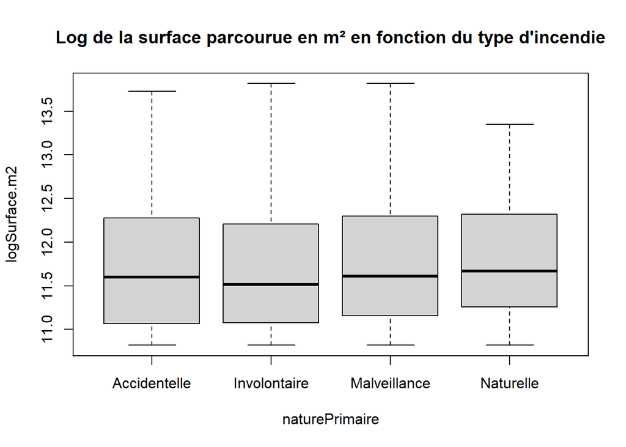

```r
boxplot(logSurface.m2 ~ naturePrimaire, data=SURFACENATURELOG,
        main = "Log de la surface parcourue en m² en fonction du type d'incendie")
```

**Interprétation :** Les boîtes à moustache montrent des résultats similaires ; bien que non égaux. Cela laisse à penser une indépendance des deux variables.

##### **Histogramme**

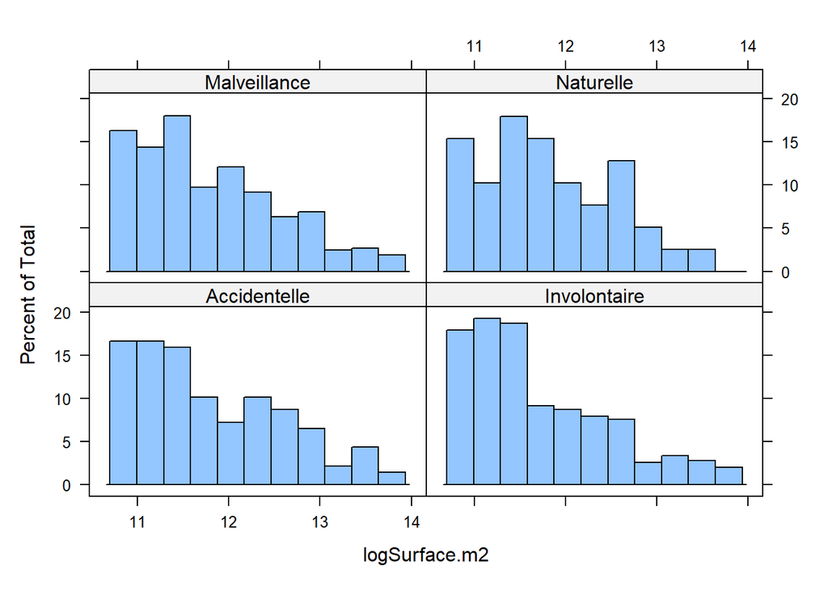

```r
library(lattice)
histogram(~ logSurface.m2 | naturePrimaire, data = SURFACENATURELOG)
```

**Interprétation :** On voit néanmoins dans les histogramme d’autres différences : Là où la surface des incendies naturels est un peu plus variable, celles de ceux d’origine humaine se concentre majoritairement sur des surfaces plus restreintes, surtout pour les incendies involontaire.

#### Analyse Statistique : Rapport de corrélation

```r
res_lm = lm(logSurface.m2~naturePrimaire, data = SURFACENATURELOG)
rap_cor = sqrt(summary(res_lm)$r.squared)
rap_cor
```

```
## [1] 0.0544541
```

On se retrouve avec un rapport de corrélation inférieur à 0,1.

### Certaines périodes de l’année sont-elles associées à des incendies de plus grande ampleur en termes de surface affectée ?

#### **Hypothèses**

- **H0** : La surface parcourue par les incendies est identique quel que soit le mois de l’année.
- **H1** : La surface parcourue par les incendies varie selon le mois de l’année.

#### Chargement des données

```r
Surface_vs_Mois <- read.csv("../Exports/surface_vs_mois.csv",
                            encoding = "UTF-8",
                            stringsAsFactors=TRUE)
View(Surface_vs_Mois)

Surface_vs_Mois_LOG = cbind(Surface_vs_Mois[, 1:2],
                            log(Surface_vs_Mois[,3]),
                            Surface_vs_Mois[,4])
colnames(Surface_vs_Mois_LOG)[3] <- "logSurface"
colnames(Surface_vs_Mois_LOG)[4] <- "mois"

summary(Surface_vs_Mois)
```

```
##        id           code_INSEE   surface_parcouru_m2      mois
##  Min.   :   1.0   2B185  :  16   Min.   :  50000     Jul    :266
##  1st Qu.: 301.2   2B123  :  10   1st Qu.:  69519     Aug    :242
##  Median : 601.5   2B079  :   9   Median : 102831     Mar    :144
##  Mean   : 601.5   2B143  :   9   Mean   : 179540     Sep    :137
##  3rd Qu.: 901.8   6074   :   9   3rd Qu.: 204950     Jun    :101
##  Max.   :1202.0   66030  :   7   Max.   :1000000     Feb    : 99
##                   (Other):1142                       (Other):213
```

#### Analyse Graphique

##### **Boxplot : Logarithme de la surface selon le mois**

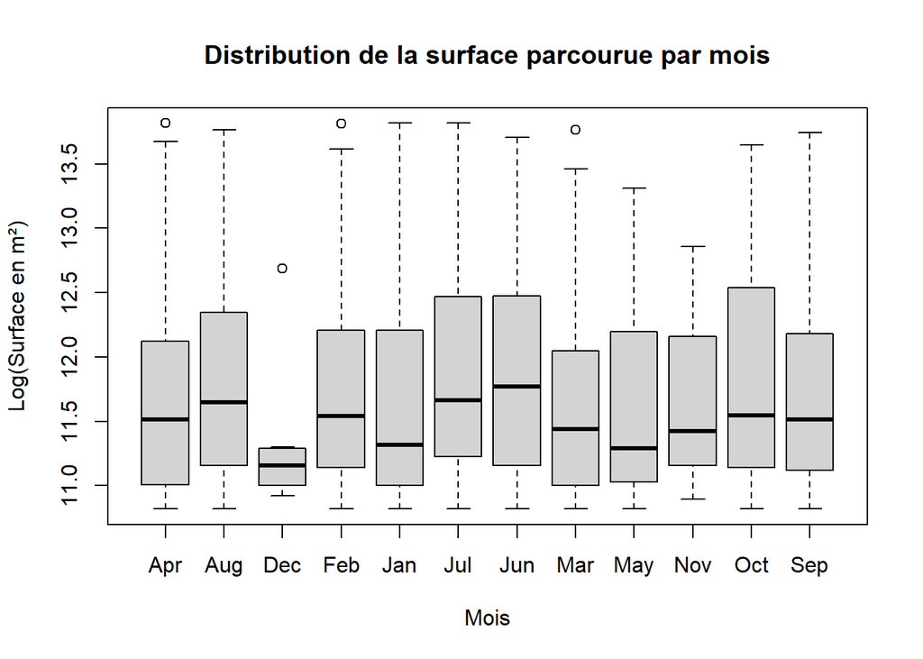

```r
boxplot(logSurface ~ mois,
        data = Surface_vs_Mois_LOG,
        main = "Distribution de la surface parcourue par mois",
        ylab = "Log(Surface en m²)",
        xlab = "Mois")
```

La distribution de la surface parcourue (logSurface) est relativement uniforme selon les mois de l’année. Seul le mois de décembre présente une distribution sensiblement différente, avec des surfaces plus faibles et moins dispersées. À l’exception de décembre, la surface brûlée ne semble pas varier de manière significative d’un mois à l’autre.  
Cela suggère l’absence d’un lien fort entre le mois et l’ampleur des incendies.

##### **Histogrammes conditionnels**

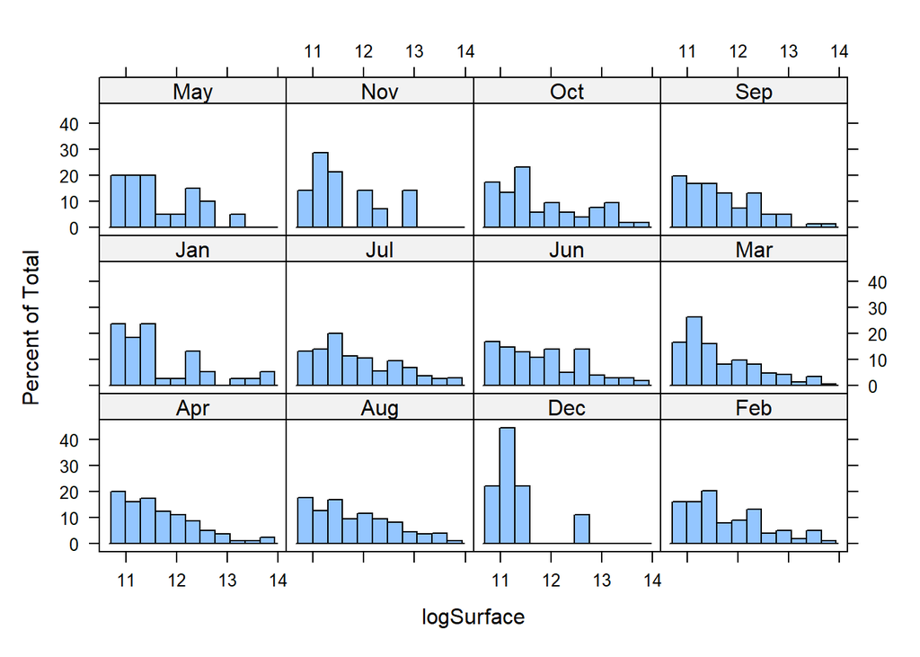

```r
library(lattice)
histogram(~ logSurface | mois, data = Surface_vs_Mois_LOG)
```

La distribution de logSurface est globalement similaire d’un mois à l’autre, concentrée sur de faibles valeurs. Le mois de décembre se démarque avec une distribution plus resserrée autour de faibles surfaces. Pour les autres mois, la répartition est assez homogène, ce qui confirme l’absence de saisonnalité marquée.

##### **Stripchart : dispersion individuelle**

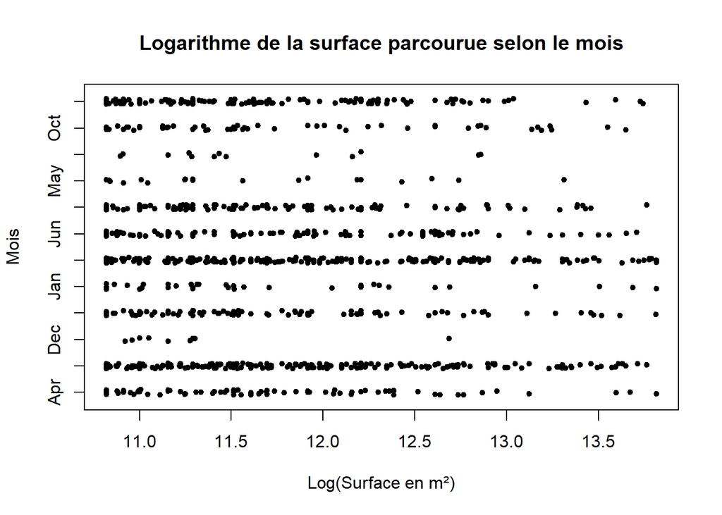

```r
stripchart(logSurface ~ mois, data = Surface_vs_Mois_LOG,
           method = "jitter",
           pch = 20,
           main = "Logarithme de la surface parcourue selon le mois",
           xlab = "Log(Surface en m²)",
           ylab = "Mois")
```

La dispersion des valeurs est assez régulière entre les mois. Le mois de décembre montre cependant une concentration autour de faibles surfaces. Dans l’ensemble, il n’émerge pas de tendance saisonnière marquée.

#### Analyse Statistique : Rapport de corrélation

```r
res_lm = lm(logSurface ~ mois, data = Surface_vs_Mois_LOG)
rap_cor = sqrt(summary(res_lm)$r.squared)
rap_cor
```

```
## [1] 0.1218786
```

Le rapport de corrélation obtenu est d’environ 0.12, indiquant une très faible liaison.

Ce faible rapport de corrélation confirme que le mois de l’année explique très peu la variabilité de la surface parcourue.  
Il corrobore les observations graphiques d’une relative stabilité de la surface brûlée tout au long de l’année.

#### Conclusion

Toutes les analyses, qu’elles soient graphiques ou statistiques, mènent à la même conclusion : **Il n’existe pas d’association significative entre le mois de l’année et la surface parcourue par les incendies.**  
La surface brûlée reste relativement stable au fil des mois, à l’exception d’une légère particularité observée pour le mois de décembre. Ainsi, **nous ne rejetons pas l’hypothèse nulle (H₀)**.

### La position géographique des communes, notamment leur latitude, a-t-elle un impact sur la gravité des incendies mesurée en surface parcourue ?

#### Hypothèses

- **H0** : Il n’existe aucune relation entre la latitude et la surface parcourue par les incendies.
- **H1** : Il existe une relation entre la latitude et la surface parcourue par les incendies.

#### Chargement des données

```r
Surface_vs_Latitude <- read.csv("../Exports/surface_vs_latitude.csv",
                                encoding = "UTF-8",
                                stringsAsFactors=TRUE)

Surface_vs_Latitude_LOG <- cbind(log(Surface_vs_Latitude[, 1]), Surface_vs_Latitude[, 2])
colnames(Surface_vs_Latitude_LOG) <- c("logSurface", "latitude")

summary(Surface_vs_Latitude)
```

```
##  surface_parcouru_m2    latitude
##  Min.   :  50000     Min.   :-21.31
##  1st Qu.:  69519     1st Qu.: 42.76
##  Median : 102831     Median : 43.63
##  Mean   : 179540     Mean   : 43.40
##  3rd Qu.: 204950     3rd Qu.: 44.48
##  Max.   :1000000     Max.   : 49.65
```

```r
Surface_vs_Latitude_LOG_filtre <- Surface_vs_Latitude_LOG[
  Surface_vs_Latitude_LOG[, "latitude"] >= 40 & Surface_vs_Latitude_LOG[, "latitude"] <= 52,
]
Surface_vs_Latitude_LOG_filtre <- as.data.frame(Surface_vs_Latitude_LOG_filtre)
```

À l’issue du chargement des données, on observe que certaines valeurs de latitude sont anormalement basses. En particulier, la latitude minimale est de **-21.31**, ce qui correspond vraisemblablement à un territoire d’Outre-mer (par exemple, La Réunion est située autour de 21° Sud). Or, l’analyse porte ici uniquement sur les incendies en France métropolitaine. Ainsi, nous avons filtré les données pour ne conserver que les observations dont la latitude est comprise entre 40° et 52°, bornes cohérentes avec le territoire métropolitain.

#### Analyse Graphique

##### **Nuage de points**

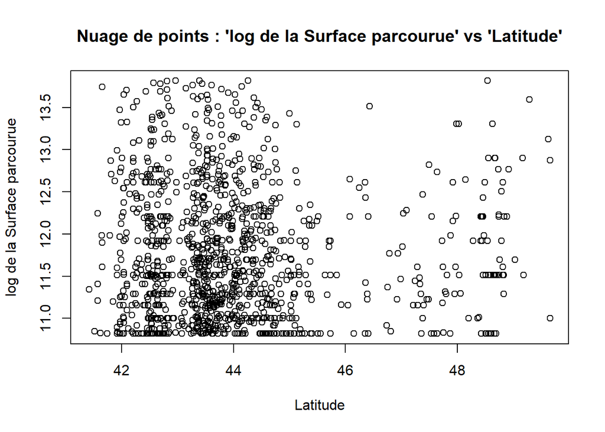

```r
plot(Surface_vs_Latitude_LOG_filtre$latitude, Surface_vs_Latitude_LOG_filtre$logSurface,
     xlab = "Latitude",
     ylab = "log de la Surface parcourue",
     main = "Nuage de points : 'log de la Surface parcourue' vs 'Latitude'"
)
```

Le nuage de points représentant la relation entre la latitude et le logarithme de la surface parcourue par les incendies ne fait apparaitre aucune tendance claire. Les points semblent répartis de manière relativement homogène sur l’ensemble des latitudes observées, sans motif linéaire évident. La concentration importante des observations autour des latitudes 42° à 45° reflète la forte exposition aux incendies dans les régions du sud de la France. Cependant, aucune corrélation visuelle forte ne se dégage entre la position nord-sud (latitude) et l’ampleur des incendies.

##### **Droite de régression**

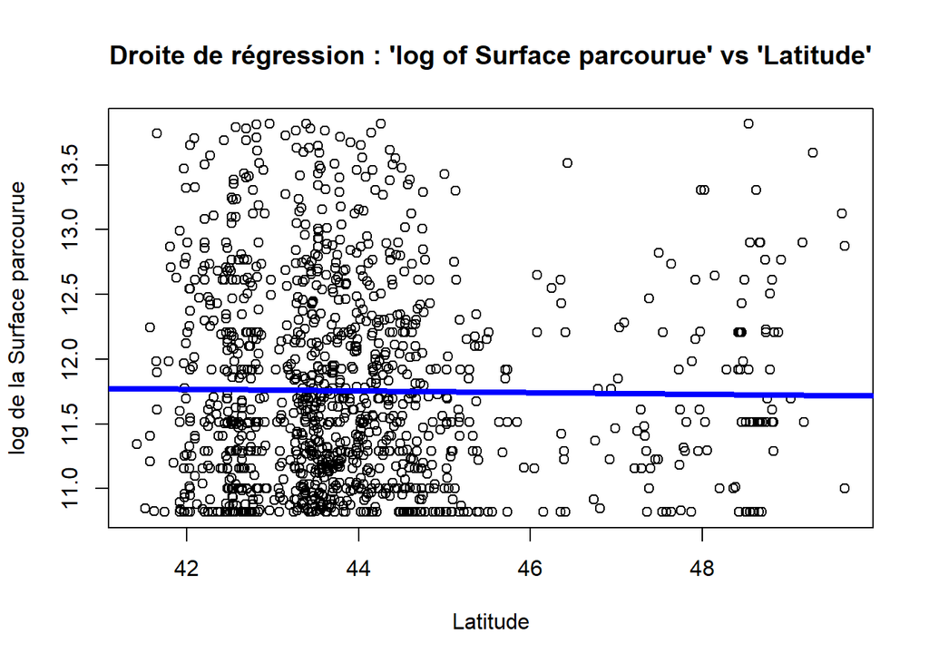

```r
reglin1 = lm(logSurface ~ latitude, Surface_vs_Latitude_LOG_filtre)
plot(Surface_vs_Latitude_LOG_filtre$latitude, Surface_vs_Latitude_LOG_filtre$logSurface,
     xlab = "Latitude",
     ylab = "log de la Surface parcourue",
     main = "Droite de régression : 'log of Surface parcourue' vs 'Latitude'"
)
abline(reglin1, col = "blue", lwd = 4)
```

L’ajout de la droite de régression au nuage de points confirme l’absence de lien linéaire significatif entre la latitude et le logarithme de la surface parcourue par les incendies. La droite est pratiquement horizontale, ce qui indique que la variation de la latitude n’entraîne pas de modification notable de la surface brûlée. Visuellement, aucun schéma de dépendance clair ne se dégage entre les deux variables.

#### Analyse statistique : Coefficient de corrélation linéaire

```r
cor(Surface_vs_Latitude_LOG_filtre$latitude
    ,Surface_vs_Latitude_LOG_filtre$logSurface)
```

```
## [1] -0.01338063
```

Le coefficient de corrélation linéaire entre la latitude et le logarithme de la surface parcourue est de **-0,013**. Cette valeur, très proche de zéro, indique qu’il n’existe pas de relation linéaire significative entre ces deux variables. Ainsi, la latitude n’a pas d’effet sur la gravité des incendies mesurée par la surface brûlée.

#### Conclusion

L’ensemble des analyses graphiques et numériques permet de conclure que la latitude n’influence pas significativement la surface parcourue par les incendies en France métropolitaine. Nous ne rejetons pas l’hypothèse nulle (H₀) : Il n’existe aucune relation entre la latitude et la surface parcourue par les incendies.